```python
import numpy as np
from scipy.io import loadmat
import matplotlib.pyplot as plt
import seaborn as sns
import cv2
import sys
import os
#import tensorflow as tf
from tensorflow import keras
from tensorflow.keras.applications import MobileNetV2
from tensorflow.keras.preprocessing.image import ImageDataGenerator
from tensorflow.keras.utils import to_categorical
from tensorflow.keras.callbacks import EarlyStopping, ModelCheckpoint
from tensorflow.keras.layers import Dense, GlobalMaxPooling2D, GlobalAveragePooling2D, \
                                    LeakyReLU, Conv2D, Flatten, \
                                    MaxPooling2D, BatchNormalization, Dropout
from sklearn.metrics import confusion_matrix, classification_report

%matplotlib inline
```

# 1-) Verinin okunması

```python
input_data = loadmat('./Task/el-yazisi-sayi.mat')
input_data
```

```
{'__header__': b'MATLAB 5.0 MAT-file Platform: posix, Created on: Fri Oct 21 17:18:28 2016',
 '__version__': '1.0',
 '__globals__': [],
 'X_test': array([[0., 0., 0., ..., 0., 0., 0.],
        [0., 0., 0., ..., 0., 0., 0.],
        [0., 0., 0., ..., 0., 0., 0.],
        ...,
        [0., 0., 0., ..., 0., 0., 0.],
        [0., 0., 0., ..., 0., 0., 0.],
        [0., 0., 0., ..., 0., 0., 0.]]),
 'X_train': array([[0., 0., 0., ..., 0., 0., 0.],
        [0., 0., 0., ..., 0., 0., 0.],
        [0., 0., 0., ..., 0., 0., 0.],
        ...,
        [0., 0., 0., ..., 0., 0., 0.],
```

[output cut: 49 more lines]

```python
X_train = input_data["X_train"].astype("float32")
X_test = input_data["X_test"].astype("float32")
y_train = input_data["y_train"]
y_test = input_data["y_test"]
X_train.shape, X_test.shape, y_train.shape, y_test.shape
```

```
((4000, 400), (1000, 400), (1, 4000), (1, 1000))
```

# 2-) 50. verinin görselleştirilmesi

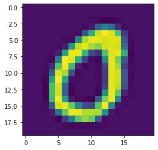

```python
plt.imshow(X_train[50].reshape(20,20))
```

```python
# shapelerin training için uygun hale getirilmesi
img_h = 20
img_w = 20
X_train = X_train.reshape(X_train.shape[0], img_h, img_w, 1)
X_test = X_test.reshape(X_test.shape[0], img_h, img_w, 1)
y_train = y_train.reshape(y_train.shape[1], 1)
y_test = y_test.reshape(y_test.shape[1], 1)
X_train.shape, X_test.shape, y_train.shape, y_test.shape
```

```
((4000, 20, 20, 1), (1000, 20, 20, 1), (4000, 1), (1000, 1))
```

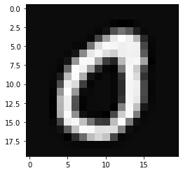

```python
plt.imshow(X_train[50], cmap = "gray")
```

```python
X_train.min(), X_train.max(), X_train.mean(), X_train.std()
```

```
(-0.13196322, 1.1276883, 0.13059708, 0.2941635)
```

```python
# 0-1 normalizasyonu yapılırken bir şeyler yolunda gitmemiş olmalı
# np.clip fonksiyonu ile pixel değerlerini 0-1 aralığına sıkıştırabiliriz
X_train = np.array([np.clip(x, 0, 1) for x in X_train])
X_test = np.array([np.clip(x, 0, 1) for x in X_test])
```

# İlk 50 verinin görselleştirilmesi

```python
# labelların da doğru olup olmadığını kontrol etmek önemli bir adım
def visualize_digit_images(image_tensor, label_tensor, interval = range(0,25), nrows = 5, ncols = 10):
    fig, axes = plt.subplots(figsize = (20,12), nrows=nrows, ncols=ncols) # plot çerçevesi oluşturma
    for ind, ax in zip(interval, axes.ravel()):
        img = image_tensor[ind]
        label = label_tensor[ind]
        ax.imshow(img, cmap = "gray")
        ax.set_title(str(label))
        ax.axis("off")
```

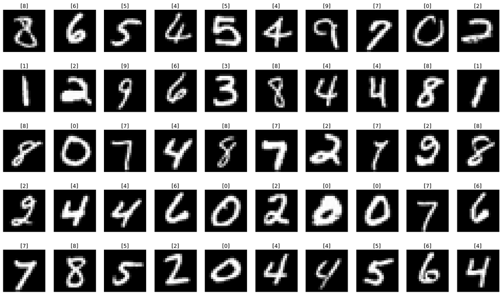

```python
visualize_digit_images(X_train, y_train, interval = range(0,50), nrows = 5, ncols = 10)
```

İlk 50 örnek için bir label hatası görülmüyor. Labellar tam sayı olarak array formatıyla kodlanmış, muhtemelen bunun için bir düzenleme yapmamız gerekebilir.

```python
# integer encodingden one hot encodinge
y_train_ohe = to_categorical(y_train, 10)
y_test_ohe = to_categorical(y_test, 10)
y_train_ohe, y_test_ohe
```

```
(array([[0., 0., 0., ..., 0., 1., 0.],
        [0., 0., 0., ..., 0., 0., 0.],
        [0., 0., 0., ..., 0., 0., 0.],
        ...,
        [1., 0., 0., ..., 0., 0., 0.],
        [0., 0., 0., ..., 0., 1., 0.],
        [0., 0., 0., ..., 0., 1., 0.]], dtype=float32),
 array([[0., 0., 0., ..., 0., 0., 0.],
        [0., 0., 0., ..., 0., 0., 0.],
        [0., 0., 0., ..., 0., 0., 0.],
        ...,
        [0., 0., 1., ..., 0., 0., 0.],
        [0., 0., 0., ..., 0., 1., 0.],
        [0., 0., 0., ..., 0., 0., 0.]], dtype=float32))
```

### Sınıf bazlı veri setinin dağılımının incelenmesi

```python
# her bir class'a ait olan image sayısını hesaplayalım
train_labels_array, train_counts_array = np.unique(y_train, return_counts=True)
print(F"Unique classlar: {train_labels_array}, \nVeri Sayıları: {train_counts_array}")
# test seti için
test_labels_array, test_counts_array = np.unique(y_test, return_counts=True)
test_labels_array, test_counts_array
```

```
Unique classlar: [0 1 2 3 4 5 6 7 8 9],
Veri Sayıları: [404 411 401 396 398 395 403 406 400 386]
```

```
(array([0, 1, 2, 3, 4, 5, 6, 7, 8, 9], dtype=uint8),
 array([ 96,  89,  99, 104, 102, 105,  97,  94, 100, 114]))
```

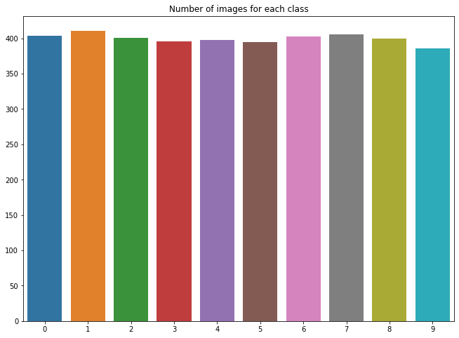

```python
plt.figure(figsize = (11,8))
sns.barplot(train_labels_array, train_counts_array)
plt.title("Number of images for each class")
plt.show()
```

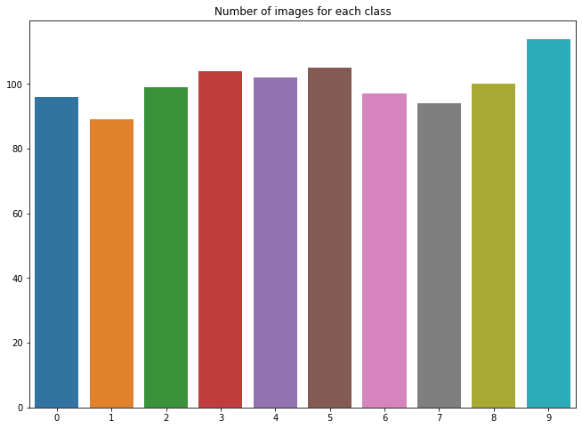

```python
plt.figure(figsize = (11,8))
sns.barplot(test_labels_array, test_counts_array)
plt.title("Number of images for each class")
plt.show()
```

Yukarıdaki histogramlara göre problemimiz "balanced" bir sınıflandırma problemidir diyebiliriz.

# İlk 1000 veri kullanılarak model oluşturulması

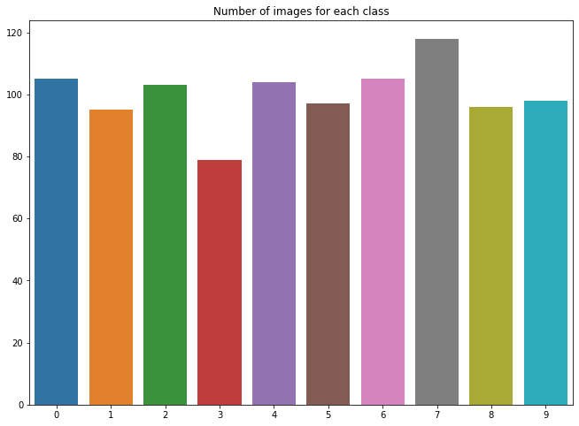

```python
# ilk 1000 veride sınıflara göre örnek sayısına bakalım(imbalance?)
train_labels_array, train_counts_array = np.unique(y_train[:1000], return_counts=True)
plt.figure(figsize = (11,8))
sns.barplot(train_labels_array, train_counts_array)
plt.title("Number of images for each class")
plt.show()
```

"3"'e ait olan veri sayısı "7"'nin 0.65 katı. İdealde her class için eşit sayıda örnek içermesi performansı iyi etkilediği için bu durum augmentation sırasında kotarılabilir. Augmentationdan sonra da örnek sayısı dağışımını kontrol etmek anlamlı olacaktır

```python
# ilk 1000 verinin alınması
X_train_subset = X_train[:1000].copy()
y_train_subset_ohe = y_train_ohe[:1000].copy()
X_train_subset.shape, y_train_subset_ohe.shape
```

```
((1000, 20, 20, 1), (1000, 10))
```

### Vanilla CNN modeli

Problemimiz image classification problemi olduğu için fully connected neural network kullanmak yerine CNN kullanmak hem accuracy hem de computation cost açısından muhtemelen daha iyi olacaktır.

```python
num_classes = 10
input_shape = (20, 20, 1)
batch_size = 64
```

```python
# Hem baseline oluşturması açısı için hem de yukarıdaki iddiamızın doğruluğunu test etmek için
# bir MLP model eğitelim
model_mlp = keras.models.Sequential()
model_mlp.add(keras.layers.Flatten(input_shape=(20,20)))
model_mlp.add(keras.layers.Dense(128, activation='relu'))
model_mlp.add(keras.layers.Dense(128, activation='relu'))
model_mlp.add(keras.layers.Dense(10, activation='softmax'))
model_mlp.summary()
```

```
Model: "sequential"
_________________________________________________________________
Layer (type)                 Output Shape              Param #
=================================================================
flatten (Flatten)            (None, 400)               0
_________________________________________________________________
dense (Dense)                (None, 128)               51328
_________________________________________________________________
dense_1 (Dense)              (None, 128)               16512
_________________________________________________________________
dense_2 (Dense)              (None, 10)                1290
=================================================================
Total params: 69,130
Trainable params: 69,130
Non-trainable params: 0
_________________________________________________________________
```

```python
# Adam optimizer problem için uygun olacaktır
opt = keras.optimizers.Adam()

# Labellarımız tam sayı olarak kalsaydı sparse categorical cross entropy loss'unu kullanmak uygun olacaktı
# one hot encoding ile dönüştürdüğümüz için categorical crossentropy kullanmak uygundur
loss_fn = keras.losses.CategoricalCrossentropy()

model_mlp.compile(optimizer = opt, loss = loss_fn,
                   metrics = ['accuracy'])
```

```python
# Best weight'i kaydeden bir call back yazalım(ileride accuracy, model size, inference time yapmak isteyebiliriz)
save_dir = "./saved_models/"
if not(os.path.exists(save_dir)):
    os.mkdir(save_dir)
model_name = "best_model_mlp"
model_checkpointer = ModelCheckpoint(save_dir + model_name + ".h5",
                                monitor='val_loss',
                                verbose=1,
                                save_best_only=True,
                                mode='min')
```

```python
history_model_mlp = model_mlp.fit(X_train_subset,
                                  y_train_subset_ohe,
                                  epochs = 100,
                                  validation_data = (X_test, y_test_ohe),
                                  batch_size = 64,
                                  callbacks=[model_checkpointer]
                                  )
```

```
Epoch 00001: val_loss improved from inf to 1.55430, saving model to ./saved_models/best_model_mlp.h5
Epoch 00002: val_loss improved from 1.55430 to 0.86010, saving model to ./saved_models/best_model_mlp.h5
Epoch 00003: val_loss improved from 0.86010 to 0.59864, saving model to ./saved_models/best_model_mlp.h5
Epoch 00004: val_loss improved from 0.59864 to 0.48855, saving model to ./saved_models/best_model_mlp.h5
Epoch 00005: val_loss improved from 0.48855 to 0.45651, saving model to ./saved_models/best_model_mlp.h5
Epoch 00006: val_loss improved from 0.45651 to 0.41590, saving model to ./saved_models/best_model_mlp.h5
Epoch 00007: val_loss improved from 0.41590 to 0.38568, saving model to ./saved_models/best_model_mlp.h5
Epoch 00008: val_loss improved from 0.38568 to 0.38130, saving model to ./saved_models/best_model_mlp.h5
Epoch 00009: val_loss improved from 0.38130 to 0.35778, saving model to ./saved_models/best_model_mlp.h5
Epoch 00010: val_loss did not improve from 0.35778
Epoch 00011: val_loss improved from 0.35778 to 0.35763, saving model to ./saved_models/best_model_mlp.h5
Epoch 00012: val_loss improved from 0.35763 to 0.35058, saving model to ./saved_models/best_model_mlp.h5
Epoch 00013: val_loss improved from 0.35058 to 0.34633, saving model to ./saved_models/best_model_mlp.h5
Epoch 00014: val_loss did not improve from 0.34633
Epoch 00015: val_loss improved from 0.34633 to 0.34525, saving model to ./saved_models/best_model_mlp.h5
Epoch 00016: val_loss did not improve from 0.34525
Epoch 00017: val_loss improved from 0.34525 to 0.33688, saving model to ./saved_models/best_model_mlp.h5
Epoch 00018: val_loss did not improve from 0.33688
Epoch 00019: val_loss did not improve from 0.33688
Epoch 00020: val_loss did not improve from 0.33688
Epoch 00021: val_loss did not improve from 0.33688
Epoch 00022: val_loss did not improve from 0.33688
Epoch 00023: val_loss did not improve from 0.33688
Epoch 00024: val_loss did not improve from 0.33688
Epoch 00025: val_loss did not improve from 0.33688
Epoch 00026: val_loss did not improve from 0.33688
Epoch 00027: val_loss did not improve from 0.33688
Epoch 00028: val_loss did not improve from 0.33688
Epoch 00029: val_loss did not improve from 0.33688
Epoch 00030: val_loss did not improve from 0.33688
Epoch 00031: val_loss did not improve from 0.33688
Epoch 00032: val_loss did not improve from 0.33688
Epoch 00033: val_loss did not improve from 0.33688
Epoch 00034: val_loss did not improve from 0.33688
Epoch 00035: val_loss did not improve from 0.33688
Epoch 00036: val_loss did not improve from 0.33688
Epoch 00037: val_loss did not improve from 0.33688
Epoch 00038: val_loss did not improve from 0.33688
Epoch 00039: val_loss did not improve from 0.33688
Epoch 00040: val_loss did not improve from 0.33688
```

[output cut: 45 more lines]

```
Epoch 00086: val_loss did not improve from 0.33688
Epoch 00087: val_loss did not improve from 0.33688
Epoch 00088: val_loss did not improve from 0.33688
Epoch 00089: val_loss did not improve from 0.33688
Epoch 00090: val_loss did not improve from 0.33688
Epoch 00091: val_loss did not improve from 0.33688
Epoch 00092: val_loss did not improve from 0.33688
Epoch 00093: val_loss did not improve from 0.33688
Epoch 00094: val_loss did not improve from 0.33688
Epoch 00095: val_loss did not improve from 0.33688
Epoch 00096: val_loss did not improve from 0.33688
Epoch 00097: val_loss did not improve from 0.33688
Epoch 00098: val_loss did not improve from 0.33688
Epoch 00099: val_loss did not improve from 0.33688
Epoch 00100: val_loss did not improve from 0.33688
```

```python
# modeli lokalden tekrar yükleyip de test yapmak, overwrite gibi problemlerin önüne geçecektir
model_mlp = keras.models.load_model(save_dir + model_name + ".h5")
model_mlp.summary()
```

```
Model: "sequential"
_________________________________________________________________
Layer (type)                 Output Shape              Param #
=================================================================
flatten (Flatten)            (None, 400)               0
_________________________________________________________________
dense (Dense)                (None, 128)               51328
_________________________________________________________________
dense_1 (Dense)              (None, 128)               16512
_________________________________________________________________
dense_2 (Dense)              (None, 10)                1290
=================================================================
Total params: 69,130
Trainable params: 69,130
Non-trainable params: 0
_________________________________________________________________
```

```python
model_mlp.evaluate(X_test, y_test_ohe)
```

```
[0.33687639236450195, 0.8949999809265137]
```

```python
def visualize_loss_evolution(history_object):
    plt.figure(figsize = (13, 8))

    plt.subplot(1, 2, 1)
    plt.plot(history_object.history['loss'], label = 'Training Loss')
    plt.plot(history_object.history['val_loss'], label = 'Test Loss')
    plt.legend()

    plt.subplot(1, 2, 2)
    plt.plot(history_object.history['accuracy'], label = 'Training Accuracy')
    plt.plot(history_object.history['val_accuracy'], label = 'Test Accuracy')
    plt.legend()
    plt.show()
```

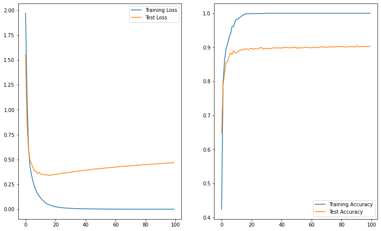

```python
visualize_loss_evolution(history_model_mlp)
```

Training ve test loss arasındaki fark, accuracyler arasındaki fark bize modelin genelleştirme becerisinin düşük olduğunu gösteriyor. Basit bir MLP modeli için kabul edilebilir bir performans. CNN ile yolumuza devam edelim.

### Zaman ve Model Büyüklüğü Analizi( MLP modeli için)

```python
%%timeit
model_mlp.predict(X_test[0].reshape(1,20,20,1))
```

```
28.4 ms ± 2 ms per loop (mean ± std. dev. of 7 runs, 10 loops each)
```

Bu kadar küçük bir model için yüksek bir inference time. Jupyter'de time ölçmektense, bir script yazıp terminalden çalıştırıp ölçmek daha anlamlı olacaktır.

```python
file_size = os.path.getsize(save_dir + model_name + ".h5")
print(F"File size of {model_name} is :", file_size/10**6, "MB")
```

```
File size of best_model_mlp is : 0.863488 MB
```

### CNN

Genel bir CNN classifier modeli yaparken convolution layerlardan sonra feature mapler Flatten() ile 1D vektör haline getirilip Dense() layerlara veriliyor. Flatten()'a alternatif olarak, özellikle accuracy'den kaybetmeden parametre sayısını azaltmak amacıyla, GlobMaxPooling2D() veya GlobAveragePooling2D() operasyonu kullanılabiliyor. Bu iki operasyon her bir dimension üzerinde max veya average pooling yaparak bir nevi feature extraction yapıyor. Inference time'dan kazanma gibi bir amaç varsa, problemde Global pooling kullanmak oldukça faydalı olabilir.

```python
def create_model(get_summary=True, glob_maxpool_or_flatten="glob"):
    if glob_maxpool_or_flatten=="glob":
        model = keras.Sequential(
    [
        keras.Input(shape=input_shape),
        Conv2D(32, kernel_size=(3, 3), activation="relu"),
        MaxPooling2D(pool_size=(2, 2)),
        Conv2D(64, kernel_size=(3, 3), activation="relu"),
        GlobalMaxPooling2D(),
        Dense(64, activation="relu"),
        # 10 tane sınıf olduğu için softmax ve 10 dense unit kullandık.
        Dense(10, activation = "softmax")
    ])
    else:
        model = keras.Sequential(
    [
        keras.Input(shape=input_shape),
        Conv2D(32, kernel_size=(3, 3), activation="relu"),
        MaxPooling2D(pool_size=(2, 2)),
        Conv2D(64, kernel_size=(3, 3), activation="relu"),
        Flatten(),
        Dense(64, activation="relu"),
        # 10 tane sınıf olduğu için softmax ve 10 dense unit kullandık.
        Dense(10, activation = "softmax")
    ])
    if get_summary:
        model.summary()
    return model
```

```python
create_model(get_summary=True, glob_maxpool_or_flatten="glob")
```

```
Model: "sequential_1"
_________________________________________________________________
Layer (type)                 Output Shape              Param #
=================================================================
conv2d (Conv2D)              (None, 18, 18, 32)        320
_________________________________________________________________
max_pooling2d (MaxPooling2D) (None, 9, 9, 32)          0
_________________________________________________________________
conv2d_1 (Conv2D)            (None, 7, 7, 64)          18496
_________________________________________________________________
global_max_pooling2d (Global (None, 64)                0
_________________________________________________________________
dense_3 (Dense)              (None, 64)                4160
_________________________________________________________________
dense_4 (Dense)              (None, 10)                650
=================================================================
Total params: 23,626
Trainable params: 23,626
Non-trainable params: 0
_________________________________________________________________
```

```
<tensorflow.python.keras.engine.sequential.Sequential at 0x7f4121f4c310>
```

```python
# keras functional api kullanarak model oluşturma(multi input-multi output networkler için çok kullanışlı)
def create_model_by_keras_api(get_summary=True, glob_maxpool_or_flatten="glob"):
    input_layer = keras.Input(shape = input_shape)
    x = Conv2D(32, kernel_size=(3, 3), activation="relu")(input_layer)
    x = MaxPooling2D(pool_size=(2, 2))(x)

    x = Conv2D(64, kernel_size=(3, 3), activation="relu")(x)
    # glob maxpool flatten'a göre parametre saysını oldukça düşüren bir layer,
    # fakat accuracy'yi kontrol etmek gerekir
    if glob_maxpool_or_flatten=="glob":
        x = GlobalMaxPooling2D()(x)
    else:
        x = Flatten()(x)

    x = Dense(64, activation="relu")(x)
    x = Dense(10, activation = "softmax")(x)

    # input ve outputları parametre olarak vermemiz gerekiyor.
    model = keras.Model(inputs = input_layer,
                                outputs = x)
    if get_summary:
        model.summary()
    return model
```

```python
model_globmaxpool_CNN_subset_train = create_model_by_keras_api(get_summary=True, glob_maxpool_or_flatten="glob")
model_globmaxpool_CNN_subset_train
```

```
Model: "functional_1"
_________________________________________________________________
Layer (type)                 Output Shape              Param #
=================================================================
input_2 (InputLayer)         [(None, 20, 20, 1)]       0
_________________________________________________________________
conv2d_2 (Conv2D)            (None, 18, 18, 32)        320
_________________________________________________________________
max_pooling2d_1 (MaxPooling2 (None, 9, 9, 32)          0
_________________________________________________________________
conv2d_3 (Conv2D)            (None, 7, 7, 64)          18496
_________________________________________________________________
global_max_pooling2d_1 (Glob (None, 64)                0
_________________________________________________________________
dense_5 (Dense)              (None, 64)                4160
_________________________________________________________________
dense_6 (Dense)              (None, 10)                650
=================================================================
Total params: 23,626
Trainable params: 23,626
Non-trainable params: 0
_________________________________________________________________
```

```
<tensorflow.python.keras.engine.functional.Functional at 0x7f41217de3d0>
```

Okunabilirlik açısından ikinci fonksiyon daha başarılı

```python
# Modeli compile edelim
opt = keras.optimizers.Adam()

loss_fn = keras.losses.CategoricalCrossentropy()

model_globmaxpool_CNN_subset_train.compile(optimizer = opt, loss = loss_fn,
                   metrics = ['accuracy'])
```

```python
model_name = "model_globmaxpool_CNN_subset_train"
model_checkpointer = ModelCheckpoint(save_dir + model_name + ".h5",
                                monitor='val_loss',
                                verbose=1,
                                save_best_only=True,
                                mode='min')
```

```python
history_globmaxpool_CNN_subset_train = model_globmaxpool_CNN_subset_train.fit(X_train_subset,
                                                                              y_train_subset_ohe,
                                                                              epochs = 100,
                                                                              validation_data = (X_test, y_test_ohe),
                                                                              batch_size = 64,
                                                                              callbacks=[model_checkpointer]
                                                                             )
```

```
Epoch 00001: val_loss improved from inf to 2.25895, saving model to ./saved_models/model_globmaxpool_CNN_subset_train.h5
Epoch 00002: val_loss improved from 2.25895 to 2.16754, saving model to ./saved_models/model_globmaxpool_CNN_subset_train.h5
Epoch 00003: val_loss improved from 2.16754 to 2.00052, saving model to ./saved_models/model_globmaxpool_CNN_subset_train.h5
Epoch 00004: val_loss improved from 2.00052 to 1.70791, saving model to ./saved_models/model_globmaxpool_CNN_subset_train.h5
Epoch 00005: val_loss improved from 1.70791 to 1.35389, saving model to ./saved_models/model_globmaxpool_CNN_subset_train.h5
Epoch 00006: val_loss improved from 1.35389 to 1.03558, saving model to ./saved_models/model_globmaxpool_CNN_subset_train.h5
Epoch 00007: val_loss improved from 1.03558 to 0.85099, saving model to ./saved_models/model_globmaxpool_CNN_subset_train.h5
Epoch 00008: val_loss improved from 0.85099 to 0.71224, saving model to ./saved_models/model_globmaxpool_CNN_subset_train.h5
Epoch 00009: val_loss improved from 0.71224 to 0.59413, saving model to ./saved_models/model_globmaxpool_CNN_subset_train.h5
Epoch 00010: val_loss improved from 0.59413 to 0.53901, saving model to ./saved_models/model_globmaxpool_CNN_subset_train.h5
Epoch 00011: val_loss improved from 0.53901 to 0.53704, saving model to ./saved_models/model_globmaxpool_CNN_subset_train.h5
Epoch 00012: val_loss improved from 0.53704 to 0.45823, saving model to ./saved_models/model_globmaxpool_CNN_subset_train.h5
Epoch 00013: val_loss improved from 0.45823 to 0.41730, saving model to ./saved_models/model_globmaxpool_CNN_subset_train.h5
Epoch 00014: val_loss improved from 0.41730 to 0.37852, saving model to ./saved_models/model_globmaxpool_CNN_subset_train.h5
Epoch 00015: val_loss improved from 0.37852 to 0.36467, saving model to ./saved_models/model_globmaxpool_CNN_subset_train.h5
Epoch 00016: val_loss improved from 0.36467 to 0.36249, saving model to ./saved_models/model_globmaxpool_CNN_subset_train.h5
Epoch 00017: val_loss improved from 0.36249 to 0.35227, saving model to ./saved_models/model_globmaxpool_CNN_subset_train.h5
Epoch 00018: val_loss improved from 0.35227 to 0.33552, saving model to ./saved_models/model_globmaxpool_CNN_subset_train.h5
Epoch 00019: val_loss improved from 0.33552 to 0.31239, saving model to ./saved_models/model_globmaxpool_CNN_subset_train.h5
Epoch 00020: val_loss improved from 0.31239 to 0.31089, saving model to ./saved_models/model_globmaxpool_CNN_subset_train.h5
Epoch 00021: val_loss did not improve from 0.31089
Epoch 00022: val_loss did not improve from 0.31089
Epoch 00023: val_loss improved from 0.31089 to 0.27784, saving model to ./saved_models/model_globmaxpool_CNN_subset_train.h5
Epoch 00024: val_loss did not improve from 0.27784
Epoch 00025: val_loss did not improve from 0.27784
Epoch 00026: val_loss improved from 0.27784 to 0.27092, saving model to ./saved_models/model_globmaxpool_CNN_subset_train.h5
Epoch 00027: val_loss did not improve from 0.27092
Epoch 00028: val_loss did not improve from 0.27092
Epoch 00029: val_loss improved from 0.27092 to 0.25530, saving model to ./saved_models/model_globmaxpool_CNN_subset_train.h5
Epoch 00030: val_loss did not improve from 0.25530
Epoch 00031: val_loss did not improve from 0.25530
Epoch 00032: val_loss did not improve from 0.25530
Epoch 00033: val_loss did not improve from 0.25530
Epoch 00034: val_loss improved from 0.25530 to 0.23584, saving model to ./saved_models/model_globmaxpool_CNN_subset_train.h5
Epoch 00035: val_loss did not improve from 0.23584
Epoch 00036: val_loss did not improve from 0.23584
Epoch 00037: val_loss improved from 0.23584 to 0.22618, saving model to ./saved_models/model_globmaxpool_CNN_subset_train.h5
Epoch 00038: val_loss did not improve from 0.22618
Epoch 00039: val_loss did not improve from 0.22618
Epoch 00040: val_loss did not improve from 0.22618
```

[output cut: 45 more lines]

```
Epoch 00086: val_loss did not improve from 0.21371
Epoch 00087: val_loss did not improve from 0.21371
Epoch 00088: val_loss did not improve from 0.21371
Epoch 00089: val_loss did not improve from 0.21371
Epoch 00090: val_loss did not improve from 0.21371
Epoch 00091: val_loss did not improve from 0.21371
Epoch 00092: val_loss did not improve from 0.21371
Epoch 00093: val_loss did not improve from 0.21371
Epoch 00094: val_loss did not improve from 0.21371
Epoch 00095: val_loss did not improve from 0.21371
Epoch 00096: val_loss did not improve from 0.21371
Epoch 00097: val_loss did not improve from 0.21371
Epoch 00098: val_loss did not improve from 0.21371
Epoch 00099: val_loss did not improve from 0.21371
Epoch 00100: val_loss did not improve from 0.21371
```

```python
# modeli lokalden tekrar yükleyip de test yapmak, overwrite gibi problemlerin önüne geçecektir
model_globmaxpool_CNN_subset_train = keras.models.load_model(save_dir + model_name + ".h5")
```

```python
model_globmaxpool_CNN_subset_train.evaluate(X_test, y_test_ohe)
```

```
[0.2137078046798706, 0.9399999976158142]
```

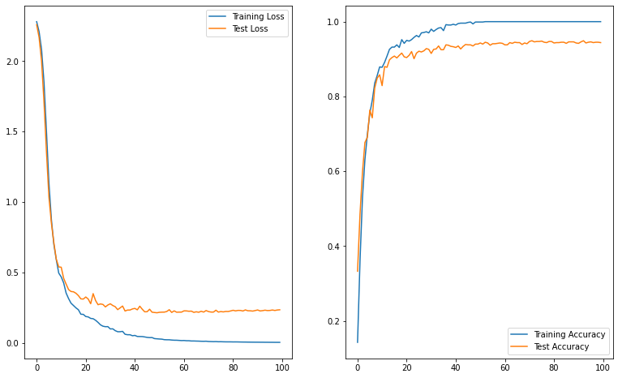

```python
visualize_loss_evolution(history_globmaxpool_CNN_subset_train)
```

MLP'ye göre daha başarılı bir model, beklediğimiz gibi sonuçlandı deneyimizin sonuçları. Parametre sayısı olarak da oldukça başarılı bir model.

### Zaman ve Model Büyüklüğü Analizi( globmaxpool_CNN modeli için)

```python
%%timeit
model_globmaxpool_CNN_subset_train.predict(X_test[0].reshape(1,20,20,1))
```

```
28.1 ms ± 805 µs per loop (mean ± std. dev. of 7 runs, 10 loops each)
```

Inference time'da küçük bir iyileşme oldu, şüphe edilecek bir durum

```python
file_size = os.path.getsize(save_dir + model_name + ".h5")
print(F"File size of {model_name} is :", file_size/10**6, "MB")
```

```
File size of model_globmaxpool_CNN_subset_train is : 0.325048 MB
```

### Flatten() Vanilla CNN

```python
model_flatten_CNN_subset_train = create_model_by_keras_api(get_summary=True, glob_maxpool_or_flatten="flatten")
model_flatten_CNN_subset_train
```

```
Model: "functional_3"
_________________________________________________________________
Layer (type)                 Output Shape              Param #
=================================================================
input_3 (InputLayer)         [(None, 20, 20, 1)]       0
_________________________________________________________________
conv2d_4 (Conv2D)            (None, 18, 18, 32)        320
_________________________________________________________________
max_pooling2d_2 (MaxPooling2 (None, 9, 9, 32)          0
_________________________________________________________________
conv2d_5 (Conv2D)            (None, 7, 7, 64)          18496
_________________________________________________________________
flatten_1 (Flatten)          (None, 3136)              0
_________________________________________________________________
dense_7 (Dense)              (None, 64)                200768
_________________________________________________________________
dense_8 (Dense)              (None, 10)                650
=================================================================
Total params: 220,234
Trainable params: 220,234
Non-trainable params: 0
_________________________________________________________________
```

```
<tensorflow.python.keras.engine.functional.Functional at 0x7f4124658a60>
```

```python
# Modeli compile edelim
opt = keras.optimizers.Adam()
loss_fn = keras.losses.CategoricalCrossentropy()

model_flatten_CNN_subset_train.compile(optimizer = opt, loss = loss_fn,
                   metrics = ['accuracy'])
```

```python
model_name = "model_flatten_CNN_subset_train"
model_checkpointer = ModelCheckpoint(save_dir + model_name + ".h5",
                                monitor='val_loss',
                                verbose=1,
                                save_best_only=True,
                                mode='min')
```

```python
history_flatten_CNN_subset_train = model_flatten_CNN_subset_train.fit(X_train_subset,
                                                                      y_train_subset_ohe,
                                                                      epochs = 100,
                                                                      validation_data = (X_test, y_test_ohe),
                                                                      batch_size = 64,
                                                                      callbacks=[model_checkpointer]
                                                                      )
```

```
Epoch 00001: val_loss improved from inf to 1.19449, saving model to ./saved_models/model_flatten_CNN_subset_train.h5
Epoch 00002: val_loss improved from 1.19449 to 0.65133, saving model to ./saved_models/model_flatten_CNN_subset_train.h5
Epoch 00003: val_loss improved from 0.65133 to 0.47863, saving model to ./saved_models/model_flatten_CNN_subset_train.h5
Epoch 00004: val_loss improved from 0.47863 to 0.37819, saving model to ./saved_models/model_flatten_CNN_subset_train.h5
Epoch 00005: val_loss improved from 0.37819 to 0.37230, saving model to ./saved_models/model_flatten_CNN_subset_train.h5
Epoch 00006: val_loss improved from 0.37230 to 0.34915, saving model to ./saved_models/model_flatten_CNN_subset_train.h5
Epoch 00007: val_loss did not improve from 0.34915
Epoch 00008: val_loss improved from 0.34915 to 0.28494, saving model to ./saved_models/model_flatten_CNN_subset_train.h5
Epoch 00009: val_loss did not improve from 0.28494
Epoch 00010: val_loss did not improve from 0.28494
Epoch 00011: val_loss did not improve from 0.28494
Epoch 00012: val_loss did not improve from 0.28494
Epoch 00013: val_loss did not improve from 0.28494
Epoch 00014: val_loss did not improve from 0.28494
Epoch 00015: val_loss did not improve from 0.28494
Epoch 00016: val_loss did not improve from 0.28494
Epoch 00017: val_loss did not improve from 0.28494
Epoch 00018: val_loss did not improve from 0.28494
Epoch 00019: val_loss did not improve from 0.28494
Epoch 00020: val_loss did not improve from 0.28494
Epoch 00021: val_loss did not improve from 0.28494
Epoch 00022: val_loss did not improve from 0.28494
Epoch 00023: val_loss did not improve from 0.28494
Epoch 00024: val_loss did not improve from 0.28494
Epoch 00025: val_loss did not improve from 0.28494
Epoch 00026: val_loss did not improve from 0.28494
Epoch 00027: val_loss did not improve from 0.28494
Epoch 00028: val_loss did not improve from 0.28494
Epoch 00029: val_loss did not improve from 0.28494
Epoch 00030: val_loss did not improve from 0.28494
Epoch 00031: val_loss did not improve from 0.28494
Epoch 00032: val_loss did not improve from 0.28494
Epoch 00033: val_loss did not improve from 0.28494
Epoch 00034: val_loss did not improve from 0.28494
Epoch 00035: val_loss did not improve from 0.28494
Epoch 00036: val_loss did not improve from 0.28494
Epoch 00037: val_loss did not improve from 0.28494
Epoch 00038: val_loss did not improve from 0.28494
Epoch 00039: val_loss did not improve from 0.28494
Epoch 00040: val_loss did not improve from 0.28494
```

[output cut: 45 more lines]

```
Epoch 00086: val_loss did not improve from 0.28494
Epoch 00087: val_loss did not improve from 0.28494
Epoch 00088: val_loss did not improve from 0.28494
Epoch 00089: val_loss did not improve from 0.28494
Epoch 00090: val_loss did not improve from 0.28494
Epoch 00091: val_loss did not improve from 0.28494
Epoch 00092: val_loss did not improve from 0.28494
Epoch 00093: val_loss did not improve from 0.28494
Epoch 00094: val_loss did not improve from 0.28494
Epoch 00095: val_loss did not improve from 0.28494
Epoch 00096: val_loss did not improve from 0.28494
Epoch 00097: val_loss did not improve from 0.28494
Epoch 00098: val_loss did not improve from 0.28494
Epoch 00099: val_loss did not improve from 0.28494
Epoch 00100: val_loss did not improve from 0.28494
```

```python
# modeli lokalden tekrar yükleyip de test yapmak, overwrite gibi problemlerin önüne geçecektir
model_flatten_CNN_subset_train = keras.models.load_model(save_dir + model_name + ".h5")
```

```python
model_flatten_CNN_subset_train.evaluate(X_test, y_test_ohe)
```

```
[0.2849436104297638, 0.9160000085830688]
```

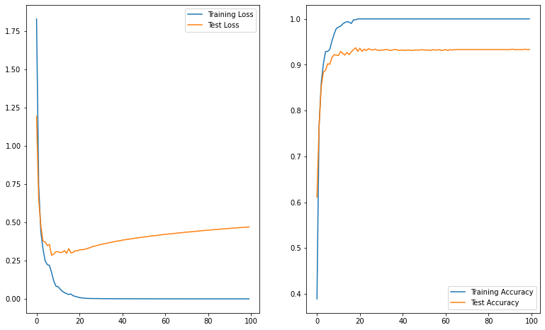

```python
visualize_loss_evolution(history_flatten_CNN_subset_train)
```

Globmaxpool modeline göre accuracy biraz daha düşük, parametre sayısı yaklaşık ~10 katı

### Zaman ve Model Büyüklüğü Analizi( flatten_CNN modeli için)

```python
%%timeit
model_flatten_CNN_subset_train.predict(X_test[0].reshape(1,20,20,1))
```

```
27.6 ms ± 675 µs per loop (mean ± std. dev. of 7 runs, 10 loops each)
```

```python
file_size = os.path.getsize(save_dir + model_name + ".h5")
print(F"File size of {model_name} is :", file_size/10**6, "MB")
```

```
File size of model_flatten_CNN_subset_train is : 2.684296 MB
```

### Custom CNN from a Kaggle article

Article Link: https://www.kaggle.com/cdeotte/how-to-choose-cnn-architecture-mnist

Bu problem için daha başarılı bir CNN nasıl yapılabilir? sorusuna cevap ararken karşılaştığım bir yazıydı. Buradaki modeli de test edelim:

```python
# En iyi architecture -->> 784 - [32C3-32C3-32C5S2] - [64C3-64C3-64C5S2] - 128 - 10
def create_custom_CNN_from_kaggle(get_summary=True, glob_maxpool_or_flatten="globmax"):

    input_layer = keras.Input(shape = input_shape)
    x = Conv2D(32, kernel_size=(3, 3), activation="relu")(input_layer)
    x = BatchNormalization()(x)

    x = Conv2D(32, kernel_size=(3, 3), activation="relu")(x)
    x = BatchNormalization()(x)

    x = Conv2D(32, kernel_size=(5, 5), strides=2,padding='same', activation="relu")(x)
    x = BatchNormalization()(x)
    x = Dropout(0.4)(x)

    x = Conv2D(64, kernel_size=(3, 3), activation="relu")(x)
    x = BatchNormalization()(x)

    x = Conv2D(64, kernel_size=(3, 3), activation="relu")(x)
    x = BatchNormalization()(x)

    x = Conv2D(64, kernel_size=(5, 5), strides=2,padding='same', activation="relu")(x)
    x = BatchNormalization()(x)
    x = Dropout(0.4)(x)
    # Flatten, Globmaxpool, or Globavgpool
    if glob_maxpool_or_flatten=="globmax":
        x = GlobalMaxPooling2D()(x)

    elif glob_maxpool_or_flatten=="globavg":
        x = GlobalAveragePooling2D()(x)

    else:
        x = Flatten()(x)

    # dense layers kısmı
    dense = Dense(128, activation='relu')(x)
    dense = BatchNormalization()(dense)
    dense = Dropout(0.4)(dense)
    dense = Dense(10, activation='softmax')(dense)

    # input ve outputları parametre olarak vermemiz gerekiyor.
    model = keras.Model(inputs = input_layer,
                        outputs = dense)
    if get_summary:
        model.summary()
    return model
```

```python
# önce kaggle'daki orjinal halini(flatten()) test edelim
model_kaggle_flatten_CNN_subset_train = create_custom_CNN_from_kaggle(get_summary=True,
                                                                      glob_maxpool_or_flatten="flatten")
```

```
Model: "functional_7"
_________________________________________________________________
Layer (type)                 Output Shape              Param #
=================================================================
input_5 (InputLayer)         [(None, 20, 20, 1)]       0
_________________________________________________________________
conv2d_12 (Conv2D)           (None, 18, 18, 32)        320
_________________________________________________________________
batch_normalization_7 (Batch (None, 18, 18, 32)        128
_________________________________________________________________
conv2d_13 (Conv2D)           (None, 16, 16, 32)        9248
_________________________________________________________________
batch_normalization_8 (Batch (None, 16, 16, 32)        128
_________________________________________________________________
conv2d_14 (Conv2D)           (None, 8, 8, 32)          25632
_________________________________________________________________
batch_normalization_9 (Batch (None, 8, 8, 32)          128
_________________________________________________________________
dropout_3 (Dropout)          (None, 8, 8, 32)          0
_________________________________________________________________
conv2d_15 (Conv2D)           (None, 6, 6, 64)          18496
_________________________________________________________________
batch_normalization_10 (Batc (None, 6, 6, 64)          256
_________________________________________________________________
conv2d_16 (Conv2D)           (None, 4, 4, 64)          36928
_________________________________________________________________
batch_normalization_11 (Batc (None, 4, 4, 64)          256
_________________________________________________________________
conv2d_17 (Conv2D)           (None, 2, 2, 64)          102464
_________________________________________________________________
batch_normalization_12 (Batc (None, 2, 2, 64)          256
_________________________________________________________________
dropout_4 (Dropout)          (None, 2, 2, 64)          0
_________________________________________________________________
flatten_3 (Flatten)          (None, 256)               0
_________________________________________________________________
dense_11 (Dense)             (None, 128)               32896
_________________________________________________________________
batch_normalization_13 (Batc (None, 128)               512
_________________________________________________________________
dropout_5 (Dropout)          (None, 128)               0
_________________________________________________________________
dense_12 (Dense)             (None, 10)                1290
=================================================================
Total params: 228,938
Trainable params: 228,106
Non-trainable params: 832
_________________________________________________________________
```

```python
# Modeli compile edelim
opt = keras.optimizers.Adam()
loss_fn = keras.losses.CategoricalCrossentropy()

model_kaggle_flatten_CNN_subset_train.compile(optimizer = opt, loss = loss_fn,
                   metrics = ['accuracy'])
```

```python
model_name = "model_kaggle_flatten_CNN_subset_train"
model_checkpointer = ModelCheckpoint(save_dir + model_name + ".h5",
                                monitor='val_loss',
                                verbose=1,
                                save_best_only=True,
                                mode='min')
```

```python
history_kaggle_flatten_CNN_subset_train = model_kaggle_flatten_CNN_subset_train.fit(X_train_subset,
                                                                                    y_train_subset_ohe,
                                                                                    epochs = 100,
                                                                                    validation_data = (X_test, y_test_ohe),
                                                                                    batch_size = 64,
                                                                                    callbacks=[model_checkpointer]
                                                                                    )
```

```
Epoch 00001: val_loss improved from inf to 2.28219, saving model to ./saved_models/model_kaggle_flatten_CNN_subset_train.h5
Epoch 00002: val_loss improved from 2.28219 to 2.23045, saving model to ./saved_models/model_kaggle_flatten_CNN_subset_train.h5
Epoch 00003: val_loss improved from 2.23045 to 2.14301, saving model to ./saved_models/model_kaggle_flatten_CNN_subset_train.h5
Epoch 00004: val_loss improved from 2.14301 to 2.04492, saving model to ./saved_models/model_kaggle_flatten_CNN_subset_train.h5
Epoch 00005: val_loss improved from 2.04492 to 1.98146, saving model to ./saved_models/model_kaggle_flatten_CNN_subset_train.h5
Epoch 00006: val_loss improved from 1.98146 to 1.94701, saving model to ./saved_models/model_kaggle_flatten_CNN_subset_train.h5
Epoch 00007: val_loss improved from 1.94701 to 1.93402, saving model to ./saved_models/model_kaggle_flatten_CNN_subset_train.h5
Epoch 00008: val_loss improved from 1.93402 to 1.90804, saving model to ./saved_models/model_kaggle_flatten_CNN_subset_train.h5
Epoch 00009: val_loss did not improve from 1.90804
Epoch 00010: val_loss did not improve from 1.90804
Epoch 00011: val_loss did not improve from 1.90804
Epoch 00012: val_loss did not improve from 1.90804
Epoch 00013: val_loss did not improve from 1.90804
Epoch 00014: val_loss did not improve from 1.90804
Epoch 00015: val_loss did not improve from 1.90804
Epoch 00016: val_loss did not improve from 1.90804
Epoch 00017: val_loss did not improve from 1.90804
Epoch 00018: val_loss did not improve from 1.90804
Epoch 00019: val_loss improved from 1.90804 to 1.84572, saving model to ./saved_models/model_kaggle_flatten_CNN_subset_train.h5
Epoch 00020: val_loss did not improve from 1.84572
Epoch 00021: val_loss did not improve from 1.84572
Epoch 00022: val_loss did not improve from 1.84572
Epoch 00023: val_loss improved from 1.84572 to 1.75237, saving model to ./saved_models/model_kaggle_flatten_CNN_subset_train.h5
Epoch 00024: val_loss improved from 1.75237 to 1.43319, saving model to ./saved_models/model_kaggle_flatten_CNN_subset_train.h5
Epoch 00025: val_loss improved from 1.43319 to 1.21780, saving model to ./saved_models/model_kaggle_flatten_CNN_subset_train.h5
Epoch 00026: val_loss improved from 1.21780 to 0.87536, saving model to ./saved_models/model_kaggle_flatten_CNN_subset_train.h5
Epoch 00027: val_loss improved from 0.87536 to 0.63791, saving model to ./saved_models/model_kaggle_flatten_CNN_subset_train.h5
Epoch 00028: val_loss improved from 0.63791 to 0.43440, saving model to ./saved_models/model_kaggle_flatten_CNN_subset_train.h5
Epoch 00029: val_loss improved from 0.43440 to 0.32427, saving model to ./saved_models/model_kaggle_flatten_CNN_subset_train.h5
Epoch 00030: val_loss improved from 0.32427 to 0.26330, saving model to ./saved_models/model_kaggle_flatten_CNN_subset_train.h5
Epoch 00031: val_loss improved from 0.26330 to 0.23354, saving model to ./saved_models/model_kaggle_flatten_CNN_subset_train.h5
Epoch 00032: val_loss improved from 0.23354 to 0.21867, saving model to ./saved_models/model_kaggle_flatten_CNN_subset_train.h5
Epoch 00033: val_loss did not improve from 0.21867
Epoch 00034: val_loss improved from 0.21867 to 0.20346, saving model to ./saved_models/model_kaggle_flatten_CNN_subset_train.h5
Epoch 00035: val_loss improved from 0.20346 to 0.18614, saving model to ./saved_models/model_kaggle_flatten_CNN_subset_train.h5
Epoch 00036: val_loss improved from 0.18614 to 0.18059, saving model to ./saved_models/model_kaggle_flatten_CNN_subset_train.h5
Epoch 00037: val_loss improved from 0.18059 to 0.16465, saving model to ./saved_models/model_kaggle_flatten_CNN_subset_train.h5
Epoch 00038: val_loss improved from 0.16465 to 0.14256, saving model to ./saved_models/model_kaggle_flatten_CNN_subset_train.h5
Epoch 00039: val_loss improved from 0.14256 to 0.14127, saving model to ./saved_models/model_kaggle_flatten_CNN_subset_train.h5
Epoch 00040: val_loss did not improve from 0.14127
```

[output cut: 45 more lines]

```
Epoch 00086: val_loss did not improve from 0.12656
Epoch 00087: val_loss did not improve from 0.12656
Epoch 00088: val_loss did not improve from 0.12656
Epoch 00089: val_loss did not improve from 0.12656
Epoch 00090: val_loss did not improve from 0.12656
Epoch 00091: val_loss did not improve from 0.12656
Epoch 00092: val_loss did not improve from 0.12656
Epoch 00093: val_loss did not improve from 0.12656
Epoch 00094: val_loss did not improve from 0.12656
Epoch 00095: val_loss did not improve from 0.12656
Epoch 00096: val_loss did not improve from 0.12656
Epoch 00097: val_loss did not improve from 0.12656
Epoch 00098: val_loss did not improve from 0.12656
Epoch 00099: val_loss did not improve from 0.12656
Epoch 00100: val_loss did not improve from 0.12656
```

```python
# best modeli lokalden tekrar yükleyip de test yapmak, overwrite gibi problemlerin önüne geçecektir
model_kaggle_flatten_CNN_subset_train = keras.models.load_model(save_dir + model_name + ".h5")
```

```python
model_kaggle_flatten_CNN_subset_train.evaluate(X_test, y_test_ohe)
```

```
[0.12656162679195404, 0.972000002861023]
```

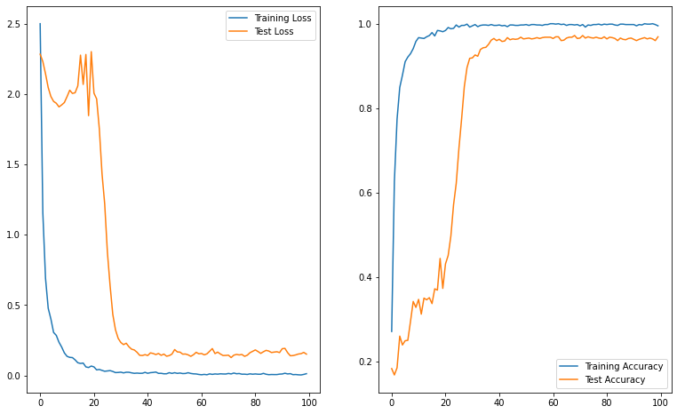

```python
visualize_loss_evolution(history_kaggle_flatten_CNN_subset_train)
```

Accuracy %93.99'den %97.20'ye yükseldi, oldukça başarılı bir artış. Modelin hızlıca converge olmaması genellikle genelleştirme becerisi açısından iyi olarak yorumlanır. Muhtemelen Dropout'un etkisi olarak bunu gözlemliyoruz

### Zaman ve Model Büyüklüğü Analizi( kaggle_flatten_CNN modeli için)

```python
%%timeit
model_kaggle_flatten_CNN_subset_train.predict(X_test[0].reshape(1,20,20,1))
```

```
29 ms ± 1.05 ms per loop (mean ± std. dev. of 7 runs, 10 loops each)
```

```python
file_size = os.path.getsize(save_dir + model_name + ".h5")
print(F"File size of {model_name} is :", file_size/10**6, "MB")
```

```
File size of model_kaggle_flatten_CNN_subset_train is : 2.885984 MB
```

Bu model bizim vanilla globmaxpool'lu CNN modelimizin neredeyse 10 katı, accuracy-speed tradeofflarına göre karar verilecektir.

#### Flatten'ı Globmaxpool'a çevirelim

```python
model_kaggle_glob_CNN_subset_train = create_custom_CNN_from_kaggle(glob_maxpool_or_flatten="globmax")
```

```
Model: "functional_9"
_________________________________________________________________
Layer (type)                 Output Shape              Param #
=================================================================
input_6 (InputLayer)         [(None, 20, 20, 1)]       0
_________________________________________________________________
conv2d_18 (Conv2D)           (None, 18, 18, 32)        320
_________________________________________________________________
batch_normalization_14 (Batc (None, 18, 18, 32)        128
_________________________________________________________________
conv2d_19 (Conv2D)           (None, 16, 16, 32)        9248
_________________________________________________________________
batch_normalization_15 (Batc (None, 16, 16, 32)        128
_________________________________________________________________
conv2d_20 (Conv2D)           (None, 8, 8, 32)          25632
_________________________________________________________________
batch_normalization_16 (Batc (None, 8, 8, 32)          128
_________________________________________________________________
dropout_6 (Dropout)          (None, 8, 8, 32)          0
_________________________________________________________________
conv2d_21 (Conv2D)           (None, 6, 6, 64)          18496
_________________________________________________________________
batch_normalization_17 (Batc (None, 6, 6, 64)          256
_________________________________________________________________
conv2d_22 (Conv2D)           (None, 4, 4, 64)          36928
_________________________________________________________________
batch_normalization_18 (Batc (None, 4, 4, 64)          256
_________________________________________________________________
conv2d_23 (Conv2D)           (None, 2, 2, 64)          102464
_________________________________________________________________
batch_normalization_19 (Batc (None, 2, 2, 64)          256
_________________________________________________________________
dropout_7 (Dropout)          (None, 2, 2, 64)          0
_________________________________________________________________
global_max_pooling2d_2 (Glob (None, 64)                0
_________________________________________________________________
dense_13 (Dense)             (None, 128)               8320
_________________________________________________________________
batch_normalization_20 (Batc (None, 128)               512
_________________________________________________________________
dropout_8 (Dropout)          (None, 128)               0
_________________________________________________________________
dense_14 (Dense)             (None, 10)                1290
=================================================================
Total params: 204,362
Trainable params: 203,530
Non-trainable params: 832
_________________________________________________________________
```

```python
# Modeli compile edelim
opt = keras.optimizers.Adam()
loss_fn = keras.losses.CategoricalCrossentropy()

model_kaggle_glob_CNN_subset_train.compile(optimizer = opt, loss = loss_fn,
                   metrics = ['accuracy'])
```

```python
model_name = "model_kaggle_glob_CNN_subset_train"
model_checkpointer = ModelCheckpoint(save_dir + model_name + ".h5",
                                    monitor='val_loss',
                                    verbose=1,
                                    save_best_only=True,
                                    mode='min')
```

```python
history_kaggle_glob_CNN_subset_train = model_kaggle_glob_CNN_subset_train.fit(X_train_subset,
                                                                              y_train_subset_ohe,
                                                                              epochs = 100,
                                                                              validation_data = (X_test, y_test_ohe),
                                                                              batch_size = 64,
                                                                              callbacks=[model_checkpointer]
                                                                              )
```

```
Epoch 00001: val_loss improved from inf to 2.30602, saving model to ./saved_models/model_kaggle_glob_CNN_subset_train.h5
Epoch 00002: val_loss did not improve from 2.30602
Epoch 00003: val_loss improved from 2.30602 to 2.28267, saving model to ./saved_models/model_kaggle_glob_CNN_subset_train.h5
Epoch 00004: val_loss improved from 2.28267 to 2.25074, saving model to ./saved_models/model_kaggle_glob_CNN_subset_train.h5
Epoch 00005: val_loss improved from 2.25074 to 2.21829, saving model to ./saved_models/model_kaggle_glob_CNN_subset_train.h5
Epoch 00006: val_loss improved from 2.21829 to 2.16847, saving model to ./saved_models/model_kaggle_glob_CNN_subset_train.h5
Epoch 00007: val_loss improved from 2.16847 to 2.10939, saving model to ./saved_models/model_kaggle_glob_CNN_subset_train.h5
Epoch 00008: val_loss improved from 2.10939 to 2.08355, saving model to ./saved_models/model_kaggle_glob_CNN_subset_train.h5
Epoch 00009: val_loss improved from 2.08355 to 2.00369, saving model to ./saved_models/model_kaggle_glob_CNN_subset_train.h5
Epoch 00010: val_loss did not improve from 2.00369
Epoch 00011: val_loss did not improve from 2.00369
Epoch 00012: val_loss did not improve from 2.00369
Epoch 00013: val_loss did not improve from 2.00369
Epoch 00014: val_loss did not improve from 2.00369
Epoch 00015: val_loss did not improve from 2.00369
Epoch 00016: val_loss did not improve from 2.00369
Epoch 00017: val_loss improved from 2.00369 to 1.79792, saving model to ./saved_models/model_kaggle_glob_CNN_subset_train.h5
Epoch 00018: val_loss improved from 1.79792 to 1.78485, saving model to ./saved_models/model_kaggle_glob_CNN_subset_train.h5
Epoch 00019: val_loss improved from 1.78485 to 1.65994, saving model to ./saved_models/model_kaggle_glob_CNN_subset_train.h5
Epoch 00020: val_loss improved from 1.65994 to 1.54347, saving model to ./saved_models/model_kaggle_glob_CNN_subset_train.h5
Epoch 00021: val_loss improved from 1.54347 to 1.35300, saving model to ./saved_models/model_kaggle_glob_CNN_subset_train.h5
Epoch 00022: val_loss improved from 1.35300 to 1.18814, saving model to ./saved_models/model_kaggle_glob_CNN_subset_train.h5
Epoch 00023: val_loss did not improve from 1.18814
Epoch 00024: val_loss did not improve from 1.18814
Epoch 00025: val_loss improved from 1.18814 to 1.04517, saving model to ./saved_models/model_kaggle_glob_CNN_subset_train.h5
Epoch 00026: val_loss improved from 1.04517 to 0.85077, saving model to ./saved_models/model_kaggle_glob_CNN_subset_train.h5
Epoch 00027: val_loss improved from 0.85077 to 0.77172, saving model to ./saved_models/model_kaggle_glob_CNN_subset_train.h5
Epoch 00028: val_loss improved from 0.77172 to 0.63632, saving model to ./saved_models/model_kaggle_glob_CNN_subset_train.h5
Epoch 00029: val_loss improved from 0.63632 to 0.49806, saving model to ./saved_models/model_kaggle_glob_CNN_subset_train.h5
Epoch 00030: val_loss did not improve from 0.49806
Epoch 00031: val_loss did not improve from 0.49806
Epoch 00032: val_loss improved from 0.49806 to 0.43667, saving model to ./saved_models/model_kaggle_glob_CNN_subset_train.h5
Epoch 00033: val_loss improved from 0.43667 to 0.31965, saving model to ./saved_models/model_kaggle_glob_CNN_subset_train.h5
Epoch 00034: val_loss improved from 0.31965 to 0.30168, saving model to ./saved_models/model_kaggle_glob_CNN_subset_train.h5
Epoch 00035: val_loss improved from 0.30168 to 0.26181, saving model to ./saved_models/model_kaggle_glob_CNN_subset_train.h5
Epoch 00036: val_loss improved from 0.26181 to 0.20200, saving model to ./saved_models/model_kaggle_glob_CNN_subset_train.h5
Epoch 00037: val_loss improved from 0.20200 to 0.19462, saving model to ./saved_models/model_kaggle_glob_CNN_subset_train.h5
Epoch 00038: val_loss did not improve from 0.19462
Epoch 00039: val_loss improved from 0.19462 to 0.17607, saving model to ./saved_models/model_kaggle_glob_CNN_subset_train.h5
Epoch 00040: val_loss improved from 0.17607 to 0.16434, saving model to ./saved_models/model_kaggle_glob_CNN_subset_train.h5
```

[output cut: 45 more lines]

```
Epoch 00086: val_loss did not improve from 0.11550
Epoch 00087: val_loss did not improve from 0.11550
Epoch 00088: val_loss did not improve from 0.11550
Epoch 00089: val_loss did not improve from 0.11550
Epoch 00090: val_loss did not improve from 0.11550
Epoch 00091: val_loss did not improve from 0.11550
Epoch 00092: val_loss did not improve from 0.11550
Epoch 00093: val_loss did not improve from 0.11550
Epoch 00094: val_loss did not improve from 0.11550
Epoch 00095: val_loss did not improve from 0.11550
Epoch 00096: val_loss did not improve from 0.11550
Epoch 00097: val_loss did not improve from 0.11550
Epoch 00098: val_loss did not improve from 0.11550
Epoch 00099: val_loss did not improve from 0.11550
Epoch 00100: val_loss did not improve from 0.11550
```

```python
# best modeli lokalden tekrar yükleyip de test yapmak, overwrite gibi problemlerin önüne geçecektir
model_kaggle_glob_CNN_subset_train = keras.models.load_model(save_dir + model_name + ".h5")
```

```python
model_kaggle_glob_CNN_subset_train.evaluate(X_test, y_test_ohe)
```

```
[0.11549541354179382, 0.9639999866485596]
```

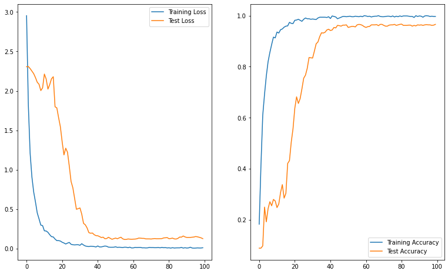

```python
visualize_loss_evolution(history_kaggle_glob_CNN_subset_train)
```

Bir önceki kaggle_flatten() modeline göre %0.8'lik bir düşüş oldu, accuracy-speed tradeoff'una göre karar vereceğiz.

### Zaman ve Model Büyüklüğü Analizi( kaggle_glob_CNN modeli için)

```python
%%timeit
model_kaggle_glob_CNN_subset_train.predict(X_test[0].reshape(1,20,20,1))
```

```
30.1 ms ± 957 µs per loop (mean ± std. dev. of 7 runs, 10 loops each)
```

```python
file_size = os.path.getsize(save_dir + model_name + ".h5")
print(F"File size of {model_name} is :", file_size/10**6, "MB")
```

```
File size of model_kaggle_glob_CNN_subset_train is : 2.591184 MB
```

Bu kez GlobMaxPool kullanmak kaydadeğer bir parametre sayısı azalması getirmedi. Bunun sebebi zaten oldukça açık: giren input_shape(batch_size,2,2,64) olduğu için flatten() bunu 2x2x64 uzunluğunda bir vektöre dönüştürürken globmaxpool() ise 1x1x64 uzunluğunda bir vektöre dönüştürüyor. Yani GlobMaxPool() giren input tensörü ne kadar büyük ise o kadar çok küçültme sağlıyor. Bunu akılda tutarak probleme çözüm bulmak anlamlı olacaktır.

### Kaggle modeli hem globmaxpool hem globaveragepool'dan geçirmek

Not: Sadece GlobAveragePooling2D() ile olan deneyleri de yapmıştım ama notebook'u biraz kısa tutmak için onları kaldırdım

Bir feature vektörünün maximum'u anlamlı olduğu kadar average'ı da anlamlı olabiliyor. Bu bilgiyi de işleyen bir model daha iyi sonuçlar verebilir. Bunu test edelim

```python
def create_maxpool_avgpool_concat_kaggle_model(get_summary=True):
    # globmaxpool ve globavgpool'un çıktılarını concat edebilmek için keras functional api ile yazmamız gerekiyor.
    input_layer = keras.Input(shape = input_shape)
    x = Conv2D(32, kernel_size=(3, 3), activation="relu")(input_layer)
    x = BatchNormalization()(x)

    x = Conv2D(32, kernel_size=(3, 3), activation="relu")(x)
    x = BatchNormalization()(x)

    x = Conv2D(32, kernel_size=(5, 5), strides=2,padding='same', activation="relu")(x)
    x = BatchNormalization()(x)
    x = Dropout(0.4)(x)

    x = Conv2D(64, kernel_size=(3, 3), activation="relu")(x)
    x = BatchNormalization()(x)

    x = Conv2D(64, kernel_size=(3, 3), activation="relu")(x)
    x = BatchNormalization()(x)

    x = Conv2D(64, kernel_size=(5, 5), strides=2,padding='same', activation="relu")(x)
    x = BatchNormalization()(x)
    x = Dropout(0.4)(x)
    # ardışıl convolution bloklarından sonra elde ettiğimiz feature map'i ayrı ayrı globmax ve globavgden geçiriyoruz
    glob_max_pool = GlobalMaxPooling2D()(x)
    glob_avg_pool = GlobalAveragePooling2D()(x)
    # glob çıktılarının concat edilmesi
    concat_max_and_avg_layer = keras.layers.Concatenate()([glob_max_pool, glob_avg_pool])
    # dense layers kısmı
    dense = Dense(128, activation='relu')(concat_max_and_avg_layer)
    dense = BatchNormalization()(dense)
    dense = Dropout(0.4)(dense)
    dense = Dense(10, activation='softmax')(dense)

    # input ve outputları parametre olarak vermemiz gerekiyor.
    model_concat = keras.Model(inputs = input_layer,
                        outputs = dense)
    if get_summary:
        model_concat.summary()
    return model_concat
```

```python
model_kaggle_globavg_concat_CNN_subset_train = create_maxpool_avgpool_concat_kaggle_model(get_summary=True)
```

```
Model: "functional_11"
__________________________________________________________________________________________________
Layer (type)                    Output Shape         Param #     Connected to
==================================================================================================
input_7 (InputLayer)            [(None, 20, 20, 1)]  0
__________________________________________________________________________________________________
conv2d_24 (Conv2D)              (None, 18, 18, 32)   320         input_7[0][0]
__________________________________________________________________________________________________
batch_normalization_21 (BatchNo (None, 18, 18, 32)   128         conv2d_24[0][0]
__________________________________________________________________________________________________
conv2d_25 (Conv2D)              (None, 16, 16, 32)   9248        batch_normalization_21[0][0]
__________________________________________________________________________________________________
batch_normalization_22 (BatchNo (None, 16, 16, 32)   128         conv2d_25[0][0]
__________________________________________________________________________________________________
conv2d_26 (Conv2D)              (None, 8, 8, 32)     25632       batch_normalization_22[0][0]
__________________________________________________________________________________________________
batch_normalization_23 (BatchNo (None, 8, 8, 32)     128         conv2d_26[0][0]
__________________________________________________________________________________________________
dropout_9 (Dropout)             (None, 8, 8, 32)     0           batch_normalization_23[0][0]
__________________________________________________________________________________________________
conv2d_27 (Conv2D)              (None, 6, 6, 64)     18496       dropout_9[0][0]
__________________________________________________________________________________________________
batch_normalization_24 (BatchNo (None, 6, 6, 64)     256         conv2d_27[0][0]
__________________________________________________________________________________________________
conv2d_28 (Conv2D)              (None, 4, 4, 64)     36928       batch_normalization_24[0][0]
__________________________________________________________________________________________________
batch_normalization_25 (BatchNo (None, 4, 4, 64)     256         conv2d_28[0][0]
__________________________________________________________________________________________________
conv2d_29 (Conv2D)              (None, 2, 2, 64)     102464      batch_normalization_25[0][0]
__________________________________________________________________________________________________
batch_normalization_26 (BatchNo (None, 2, 2, 64)     256         conv2d_29[0][0]
__________________________________________________________________________________________________
dropout_10 (Dropout)            (None, 2, 2, 64)     0           batch_normalization_26[0][0]
__________________________________________________________________________________________________
global_max_pooling2d_3 (GlobalM (None, 64)           0           dropout_10[0][0]
__________________________________________________________________________________________________
global_average_pooling2d (Globa (None, 64)           0           dropout_10[0][0]
__________________________________________________________________________________________________
concatenate (Concatenate)       (None, 128)          0           global_max_pooling2d_3[0][0]
                                                                 global_average_pooling2d[0][0]
__________________________________________________________________________________________________
dense_15 (Dense)                (None, 128)          16512       concatenate[0][0]
__________________________________________________________________________________________________
batch_normalization_27 (BatchNo (None, 128)          512         dense_15[0][0]
__________________________________________________________________________________________________
dropout_11 (Dropout)            (None, 128)          0           batch_normalization_27[0][0]
__________________________________________________________________________________________________
dense_16 (Dense)                (None, 10)           1290        dropout_11[0][0]
==================================================================================================
Total params: 212,554
Trainable params: 211,722
Non-trainable params: 832
__________________________________________________________________________________________________
```

```python
# Modeli compile edelim
opt = keras.optimizers.Adam()
loss_fn = keras.losses.CategoricalCrossentropy()

model_kaggle_globavg_concat_CNN_subset_train.compile(optimizer = opt, loss = loss_fn,
                   metrics = ['accuracy'])
```

```python
model_name = "model_kaggle_globavg_concat_CNN_subset_train"
model_checkpointer = ModelCheckpoint(save_dir + model_name + ".h5",
                                    monitor='val_loss',
                                    verbose=1,
                                    save_best_only=True,
                                    mode='min')
```

```python
history_kaggle_globavg_concat_CNN_subset_train = model_kaggle_globavg_concat_CNN_subset_train.fit(X_train_subset,
                                                                              y_train_subset_ohe,
                                                                              epochs = 100,
                                                                              validation_data = (X_test, y_test_ohe),
                                                                              batch_size = 64,
                                                                              callbacks=[model_checkpointer]
                                                                              )
```

```
Epoch 00001: val_loss improved from inf to 2.30358, saving model to ./saved_models/model_kaggle_globavg_concat_CNN_subset_train.h5
Epoch 00002: val_loss improved from 2.30358 to 2.29966, saving model to ./saved_models/model_kaggle_globavg_concat_CNN_subset_train.h5
Epoch 00003: val_loss improved from 2.29966 to 2.27866, saving model to ./saved_models/model_kaggle_globavg_concat_CNN_subset_train.h5
Epoch 00004: val_loss improved from 2.27866 to 2.24476, saving model to ./saved_models/model_kaggle_globavg_concat_CNN_subset_train.h5
Epoch 00005: val_loss improved from 2.24476 to 2.21689, saving model to ./saved_models/model_kaggle_globavg_concat_CNN_subset_train.h5
Epoch 00006: val_loss improved from 2.21689 to 2.15274, saving model to ./saved_models/model_kaggle_globavg_concat_CNN_subset_train.h5
Epoch 00007: val_loss improved from 2.15274 to 2.11982, saving model to ./saved_models/model_kaggle_globavg_concat_CNN_subset_train.h5
Epoch 00008: val_loss did not improve from 2.11982
Epoch 00009: val_loss did not improve from 2.11982
Epoch 00010: val_loss did not improve from 2.11982
Epoch 00011: val_loss did not improve from 2.11982
Epoch 00012: val_loss did not improve from 2.11982
Epoch 00013: val_loss did not improve from 2.11982
Epoch 00014: val_loss did not improve from 2.11982
Epoch 00015: val_loss did not improve from 2.11982
Epoch 00016: val_loss did not improve from 2.11982
Epoch 00017: val_loss did not improve from 2.11982
Epoch 00018: val_loss improved from 2.11982 to 2.11893, saving model to ./saved_models/model_kaggle_globavg_concat_CNN_subset_train.h5
Epoch 00019: val_loss improved from 2.11893 to 2.11145, saving model to ./saved_models/model_kaggle_globavg_concat_CNN_subset_train.h5
Epoch 00020: val_loss improved from 2.11145 to 1.94189, saving model to ./saved_models/model_kaggle_globavg_concat_CNN_subset_train.h5
Epoch 00021: val_loss improved from 1.94189 to 1.84911, saving model to ./saved_models/model_kaggle_globavg_concat_CNN_subset_train.h5
Epoch 00022: val_loss improved from 1.84911 to 1.63006, saving model to ./saved_models/model_kaggle_globavg_concat_CNN_subset_train.h5
Epoch 00023: val_loss did not improve from 1.63006
Epoch 00024: val_loss improved from 1.63006 to 1.59129, saving model to ./saved_models/model_kaggle_globavg_concat_CNN_subset_train.h5
Epoch 00025: val_loss improved from 1.59129 to 1.43560, saving model to ./saved_models/model_kaggle_globavg_concat_CNN_subset_train.h5
Epoch 00026: val_loss improved from 1.43560 to 1.43187, saving model to ./saved_models/model_kaggle_globavg_concat_CNN_subset_train.h5
Epoch 00027: val_loss improved from 1.43187 to 1.17928, saving model to ./saved_models/model_kaggle_globavg_concat_CNN_subset_train.h5
Epoch 00028: val_loss improved from 1.17928 to 0.91372, saving model to ./saved_models/model_kaggle_globavg_concat_CNN_subset_train.h5
Epoch 00029: val_loss improved from 0.91372 to 0.69246, saving model to ./saved_models/model_kaggle_globavg_concat_CNN_subset_train.h5
Epoch 00030: val_loss did not improve from 0.69246
Epoch 00031: val_loss improved from 0.69246 to 0.55476, saving model to ./saved_models/model_kaggle_globavg_concat_CNN_subset_train.h5
Epoch 00032: val_loss improved from 0.55476 to 0.41679, saving model to ./saved_models/model_kaggle_globavg_concat_CNN_subset_train.h5
Epoch 00033: val_loss improved from 0.41679 to 0.36330, saving model to ./saved_models/model_kaggle_globavg_concat_CNN_subset_train.h5
Epoch 00034: val_loss improved from 0.36330 to 0.35783, saving model to ./saved_models/model_kaggle_globavg_concat_CNN_subset_train.h5
Epoch 00035: val_loss improved from 0.35783 to 0.33900, saving model to ./saved_models/model_kaggle_globavg_concat_CNN_subset_train.h5
Epoch 00036: val_loss improved from 0.33900 to 0.32280, saving model to ./saved_models/model_kaggle_globavg_concat_CNN_subset_train.h5
Epoch 00037: val_loss improved from 0.32280 to 0.25789, saving model to ./saved_models/model_kaggle_globavg_concat_CNN_subset_train.h5
Epoch 00038: val_loss improved from 0.25789 to 0.22758, saving model to ./saved_models/model_kaggle_globavg_concat_CNN_subset_train.h5
Epoch 00039: val_loss improved from 0.22758 to 0.22670, saving model to ./saved_models/model_kaggle_globavg_concat_CNN_subset_train.h5
Epoch 00040: val_loss improved from 0.22670 to 0.20683, saving model to ./saved_models/model_kaggle_globavg_concat_CNN_subset_train.h5
```

[output cut: 45 more lines]

```
Epoch 00086: val_loss did not improve from 0.12568
Epoch 00087: val_loss did not improve from 0.12568
Epoch 00088: val_loss did not improve from 0.12568
Epoch 00089: val_loss did not improve from 0.12568
Epoch 00090: val_loss did not improve from 0.12568
Epoch 00091: val_loss did not improve from 0.12568
Epoch 00092: val_loss did not improve from 0.12568
Epoch 00093: val_loss did not improve from 0.12568
Epoch 00094: val_loss did not improve from 0.12568
Epoch 00095: val_loss did not improve from 0.12568
Epoch 00096: val_loss did not improve from 0.12568
Epoch 00097: val_loss did not improve from 0.12568
Epoch 00098: val_loss did not improve from 0.12568
Epoch 00099: val_loss did not improve from 0.12568
Epoch 00100: val_loss did not improve from 0.12568
```

```python
# best modeli lokalden tekrar yükleyip de test yapmak, overwrite gibi problemlerin önüne geçecektir
model_kaggle_globavg_concat_CNN_subset_train = keras.models.load_model(save_dir + model_name + ".h5")
```

```python
model_kaggle_globavg_concat_CNN_subset_train.evaluate(X_test, y_test_ohe)
```

```
[0.12568427622318268, 0.9679999947547913]
```

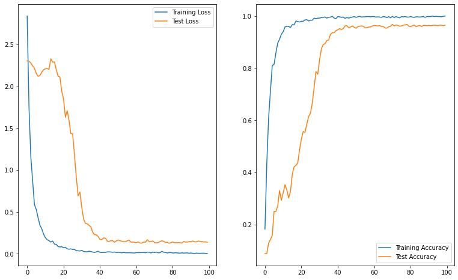

```python
visualize_loss_evolution(history_kaggle_globavg_concat_CNN_subset_train)
```

Anlamlı bir kazanç gelmedi.

### Zaman ve Model Büyüklüğü Analizi( kaggle_globavg_concat_CNN modeli için)

```python
%%timeit
model_kaggle_globavg_concat_CNN_subset_train.predict(X_test[0].reshape(1,20,20,1))
```

```
29.1 ms ± 1.3 ms per loop (mean ± std. dev. of 7 runs, 10 loops each)
```

```python
file_size = os.path.getsize(save_dir + model_name + ".h5")
print(F"File size of {model_name} is :", file_size/10**6, "MB")
```

```
File size of model_kaggle_globavg_concat_CNN_subset_train is : 2.692512 MB
```

# Verinin tamamı kullanılarak Model oluşturulması

```python
# subset data ile yaptığımız modellerde kaggle_flatten_CNN modeli optimum görünüyordu,
# bu yüzden deneylere onunla devam edelim
model_kaggle_flatten_CNN_all_train = create_custom_CNN_from_kaggle(get_summary=True,
                                                                glob_maxpool_or_flatten="flatten")
```

```
Model: "functional_13"
_________________________________________________________________
Layer (type)                 Output Shape              Param #
=================================================================
input_8 (InputLayer)         [(None, 20, 20, 1)]       0
_________________________________________________________________
conv2d_30 (Conv2D)           (None, 18, 18, 32)        320
_________________________________________________________________
batch_normalization_28 (Batc (None, 18, 18, 32)        128
_________________________________________________________________
conv2d_31 (Conv2D)           (None, 16, 16, 32)        9248
_________________________________________________________________
batch_normalization_29 (Batc (None, 16, 16, 32)        128
_________________________________________________________________
conv2d_32 (Conv2D)           (None, 8, 8, 32)          25632
_________________________________________________________________
batch_normalization_30 (Batc (None, 8, 8, 32)          128
_________________________________________________________________
dropout_12 (Dropout)         (None, 8, 8, 32)          0
_________________________________________________________________
conv2d_33 (Conv2D)           (None, 6, 6, 64)          18496
_________________________________________________________________
batch_normalization_31 (Batc (None, 6, 6, 64)          256
_________________________________________________________________
conv2d_34 (Conv2D)           (None, 4, 4, 64)          36928
_________________________________________________________________
batch_normalization_32 (Batc (None, 4, 4, 64)          256
_________________________________________________________________
conv2d_35 (Conv2D)           (None, 2, 2, 64)          102464
_________________________________________________________________
batch_normalization_33 (Batc (None, 2, 2, 64)          256
_________________________________________________________________
dropout_13 (Dropout)         (None, 2, 2, 64)          0
_________________________________________________________________
flatten_4 (Flatten)          (None, 256)               0
_________________________________________________________________
dense_17 (Dense)             (None, 128)               32896
_________________________________________________________________
batch_normalization_34 (Batc (None, 128)               512
_________________________________________________________________
dropout_14 (Dropout)         (None, 128)               0
_________________________________________________________________
dense_18 (Dense)             (None, 10)                1290
=================================================================
Total params: 228,938
Trainable params: 228,106
Non-trainable params: 832
_________________________________________________________________
```

```python
# Modeli compile edelim
opt = keras.optimizers.Adam()
loss_fn = keras.losses.CategoricalCrossentropy()

model_kaggle_flatten_CNN_all_train.compile(optimizer = opt, loss = loss_fn,
                   metrics = ['accuracy'])
```

```python
model_name = "model_kaggle_flatten_CNN_all_train"
model_checkpointer = ModelCheckpoint(save_dir + model_name + ".h5",
                                    monitor='val_loss',
                                    verbose=1,
                                    save_best_only=True,
                                    mode='min')
```

```python
history_kaggle_flatten_CNN_all_train = model_kaggle_flatten_CNN_all_train.fit(X_train,
                                                                        y_train_ohe,
                                                                        epochs = 100,
                                                                        validation_data = (X_test, y_test_ohe),
                                                                        batch_size = 64,
                                                                        callbacks=[model_checkpointer]
                                                                        )
```

```
Epoch 00001: val_loss improved from inf to 2.21871, saving model to ./saved_models/model_kaggle_flatten_CNN_all_train.h5
Epoch 00002: val_loss did not improve from 2.21871
Epoch 00003: val_loss did not improve from 2.21871
Epoch 00004: val_loss improved from 2.21871 to 1.88942, saving model to ./saved_models/model_kaggle_flatten_CNN_all_train.h5
Epoch 00005: val_loss improved from 1.88942 to 1.30328, saving model to ./saved_models/model_kaggle_flatten_CNN_all_train.h5
Epoch 00006: val_loss improved from 1.30328 to 0.58780, saving model to ./saved_models/model_kaggle_flatten_CNN_all_train.h5
Epoch 00007: val_loss improved from 0.58780 to 0.30727, saving model to ./saved_models/model_kaggle_flatten_CNN_all_train.h5
Epoch 00008: val_loss improved from 0.30727 to 0.20481, saving model to ./saved_models/model_kaggle_flatten_CNN_all_train.h5
Epoch 00009: val_loss improved from 0.20481 to 0.12909, saving model to ./saved_models/model_kaggle_flatten_CNN_all_train.h5
Epoch 00010: val_loss improved from 0.12909 to 0.08894, saving model to ./saved_models/model_kaggle_flatten_CNN_all_train.h5
Epoch 00011: val_loss did not improve from 0.08894
Epoch 00012: val_loss improved from 0.08894 to 0.08024, saving model to ./saved_models/model_kaggle_flatten_CNN_all_train.h5
Epoch 00013: val_loss improved from 0.08024 to 0.07312, saving model to ./saved_models/model_kaggle_flatten_CNN_all_train.h5
Epoch 00014: val_loss did not improve from 0.07312
Epoch 00015: val_loss improved from 0.07312 to 0.06837, saving model to ./saved_models/model_kaggle_flatten_CNN_all_train.h5
Epoch 00016: val_loss improved from 0.06837 to 0.06564, saving model to ./saved_models/model_kaggle_flatten_CNN_all_train.h5
Epoch 00017: val_loss improved from 0.06564 to 0.05693, saving model to ./saved_models/model_kaggle_flatten_CNN_all_train.h5
Epoch 00018: val_loss did not improve from 0.05693
Epoch 00019: val_loss did not improve from 0.05693
Epoch 00020: val_loss did not improve from 0.05693
Epoch 00021: val_loss improved from 0.05693 to 0.05542, saving model to ./saved_models/model_kaggle_flatten_CNN_all_train.h5
Epoch 00022: val_loss did not improve from 0.05542
Epoch 00023: val_loss did not improve from 0.05542
Epoch 00024: val_loss did not improve from 0.05542
Epoch 00025: val_loss did not improve from 0.05542
Epoch 00026: val_loss did not improve from 0.05542
Epoch 00027: val_loss did not improve from 0.05542
Epoch 00028: val_loss did not improve from 0.05542
Epoch 00029: val_loss did not improve from 0.05542
Epoch 00030: val_loss did not improve from 0.05542
Epoch 00031: val_loss did not improve from 0.05542
Epoch 00032: val_loss did not improve from 0.05542
Epoch 00033: val_loss did not improve from 0.05542
Epoch 00034: val_loss did not improve from 0.05542
Epoch 00035: val_loss did not improve from 0.05542
Epoch 00036: val_loss did not improve from 0.05542
Epoch 00037: val_loss did not improve from 0.05542
Epoch 00038: val_loss did not improve from 0.05542
Epoch 00039: val_loss did not improve from 0.05542
Epoch 00040: val_loss did not improve from 0.05542
```

[output cut: 45 more lines]

```
Epoch 00086: val_loss did not improve from 0.05542
Epoch 00087: val_loss did not improve from 0.05542
Epoch 00088: val_loss did not improve from 0.05542
Epoch 00089: val_loss did not improve from 0.05542
Epoch 00090: val_loss did not improve from 0.05542
Epoch 00091: val_loss did not improve from 0.05542
Epoch 00092: val_loss did not improve from 0.05542
Epoch 00093: val_loss did not improve from 0.05542
Epoch 00094: val_loss did not improve from 0.05542
Epoch 00095: val_loss did not improve from 0.05542
Epoch 00096: val_loss did not improve from 0.05542
Epoch 00097: val_loss did not improve from 0.05542
Epoch 00098: val_loss did not improve from 0.05542
Epoch 00099: val_loss did not improve from 0.05542
Epoch 00100: val_loss did not improve from 0.05542
```

```python
# best modeli lokalden tekrar yükleyip de test yapmak, overwrite gibi problemlerin önüne geçecektir
model_kaggle_flatten_CNN_all_train = keras.models.load_model(save_dir + model_name + ".h5")
```

```python
model_kaggle_flatten_CNN_all_train.evaluate(X_test, y_test_ohe)
```

```
[0.055416539311409, 0.9810000061988831]
```

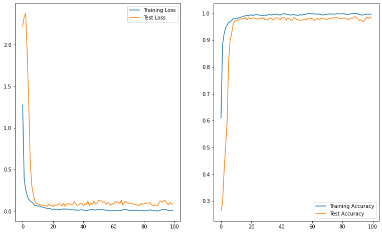

```python
visualize_loss_evolution(history_kaggle_flatten_CNN_all_train)
```

Veri setinin büyümesi learning algoritmaları için genelde performansı iyileştirir. Burda da veri setinin büyümesiyle accuracy'de anlamlı bir artış oldu. Augmentation yaparak bunu bir tık daha yukarıya çekebiliriz, deneyelim.

Not: bu modelin time size analizini yaptığımız için o kısmı atlıyorum.

## AUG part

Online augmentation için keras'ın ImageDataGenerator() objesini kullanmak oldukça faydalı oluyor. 2 farklı augmentation operasyonları dizisi kullandım. Probleme yönelik doğru augmentation'ı bulmak machine learning'in en önemli noktalarından biri, o yüzden epey enerji ayırıp deney yapmak gerekiyor. İleriki çalışma olarak bu yapılabilir gayet.

aug_soft ile train esnasında bir sorun yaşamazken aug_havy ile model öğrenmiyordu. Sebebini bulmak için saatler harcadım, hatta probleme 2 gün bakmadım. Geç teslim etmemin ana sebeplerinden biri de buydu.

```python
aug_soft = ImageDataGenerator(
        rotation_range=10,
        zoom_range = 0.10,
        width_shift_range=0.1,
        height_shift_range=0.1)
```

```python
model_kaggle_flatten_CNN_all_train_AUG_soft = create_custom_CNN_from_kaggle(get_summary=True,
                                                                         glob_maxpool_or_flatten="flatten")
```

```
Model: "functional_19"
_________________________________________________________________
Layer (type)                 Output Shape              Param #
=================================================================
input_11 (InputLayer)        [(None, 20, 20, 1)]       0
_________________________________________________________________
conv2d_48 (Conv2D)           (None, 18, 18, 32)        320
_________________________________________________________________
batch_normalization_49 (Batc (None, 18, 18, 32)        128
_________________________________________________________________
conv2d_49 (Conv2D)           (None, 16, 16, 32)        9248
_________________________________________________________________
batch_normalization_50 (Batc (None, 16, 16, 32)        128
_________________________________________________________________
conv2d_50 (Conv2D)           (None, 8, 8, 32)          25632
_________________________________________________________________
batch_normalization_51 (Batc (None, 8, 8, 32)          128
_________________________________________________________________
dropout_21 (Dropout)         (None, 8, 8, 32)          0
_________________________________________________________________
conv2d_51 (Conv2D)           (None, 6, 6, 64)          18496
_________________________________________________________________
batch_normalization_52 (Batc (None, 6, 6, 64)          256
_________________________________________________________________
conv2d_52 (Conv2D)           (None, 4, 4, 64)          36928
_________________________________________________________________
batch_normalization_53 (Batc (None, 4, 4, 64)          256
_________________________________________________________________
conv2d_53 (Conv2D)           (None, 2, 2, 64)          102464
_________________________________________________________________
batch_normalization_54 (Batc (None, 2, 2, 64)          256
_________________________________________________________________
dropout_22 (Dropout)         (None, 2, 2, 64)          0
_________________________________________________________________
flatten_5 (Flatten)          (None, 256)               0
_________________________________________________________________
dense_23 (Dense)             (None, 128)               32896
_________________________________________________________________
batch_normalization_55 (Batc (None, 128)               512
_________________________________________________________________
dropout_23 (Dropout)         (None, 128)               0
_________________________________________________________________
dense_24 (Dense)             (None, 10)                1290
=================================================================
Total params: 228,938
Trainable params: 228,106
Non-trainable params: 832
_________________________________________________________________
```

```python
# Modeli compile edelim
opt = keras.optimizers.Adam()
loss_fn = keras.losses.CategoricalCrossentropy()

model_kaggle_flatten_CNN_all_train_AUG_soft.compile(optimizer = opt, loss = loss_fn,
                   metrics = ['accuracy'])
```

```python
model_name = "model_kaggle_flatten_CNN_all_train_AUG_soft"
model_checkpointer = ModelCheckpoint(save_dir + model_name + ".h5",
                                    monitor='val_loss',
                                    verbose=1,
                                    save_best_only=True,
                                    mode='min')
```

```python
history_kaggle_flatten_CNN_all_train_AUG_soft = model_kaggle_flatten_CNN_all_train_AUG_soft.fit(aug_soft.flow(X_train,y_train_ohe, batch_size=64),
                                                                        epochs = 100,
                                                                        steps_per_epoch = X_train.shape[0]//64,
                                                                        validation_data = (X_test, y_test_ohe),
                                                                        callbacks=[model_checkpointer]
                                                                        )
```

```
Epoch 00001: val_loss improved from inf to 2.32100, saving model to ./saved_models/model_kaggle_flatten_CNN_all_train_AUG_soft.h5
Epoch 00002: val_loss did not improve from 2.32100
Epoch 00003: val_loss did not improve from 2.32100
Epoch 00004: val_loss did not improve from 2.32100
Epoch 00005: val_loss did not improve from 2.32100
Epoch 00006: val_loss did not improve from 2.32100
Epoch 00007: val_loss did not improve from 2.32100
Epoch 00008: val_loss improved from 2.32100 to 1.77824, saving model to ./saved_models/model_kaggle_flatten_CNN_all_train_AUG_soft.h5
Epoch 00009: val_loss improved from 1.77824 to 0.41946, saving model to ./saved_models/model_kaggle_flatten_CNN_all_train_AUG_soft.h5
Epoch 00010: val_loss improved from 0.41946 to 0.10502, saving model to ./saved_models/model_kaggle_flatten_CNN_all_train_AUG_soft.h5
Epoch 00011: val_loss improved from 0.10502 to 0.08542, saving model to ./saved_models/model_kaggle_flatten_CNN_all_train_AUG_soft.h5
Epoch 00012: val_loss did not improve from 0.08542
Epoch 00013: val_loss did not improve from 0.08542
Epoch 00014: val_loss improved from 0.08542 to 0.07998, saving model to ./saved_models/model_kaggle_flatten_CNN_all_train_AUG_soft.h5
Epoch 00015: val_loss improved from 0.07998 to 0.07913, saving model to ./saved_models/model_kaggle_flatten_CNN_all_train_AUG_soft.h5
Epoch 00016: val_loss did not improve from 0.07913
Epoch 00017: val_loss did not improve from 0.07913
Epoch 00018: val_loss improved from 0.07913 to 0.07282, saving model to ./saved_models/model_kaggle_flatten_CNN_all_train_AUG_soft.h5
Epoch 00019: val_loss did not improve from 0.07282
Epoch 00020: val_loss did not improve from 0.07282
Epoch 00021: val_loss did not improve from 0.07282
Epoch 00022: val_loss did not improve from 0.07282
Epoch 00023: val_loss did not improve from 0.07282
Epoch 00024: val_loss improved from 0.07282 to 0.07022, saving model to ./saved_models/model_kaggle_flatten_CNN_all_train_AUG_soft.h5
Epoch 00025: val_loss improved from 0.07022 to 0.06446, saving model to ./saved_models/model_kaggle_flatten_CNN_all_train_AUG_soft.h5
Epoch 00026: val_loss did not improve from 0.06446
Epoch 00027: val_loss did not improve from 0.06446
Epoch 00028: val_loss did not improve from 0.06446
Epoch 00029: val_loss did not improve from 0.06446
Epoch 00030: val_loss did not improve from 0.06446
Epoch 00031: val_loss did not improve from 0.06446
Epoch 00032: val_loss did not improve from 0.06446
Epoch 00033: val_loss improved from 0.06446 to 0.06360, saving model to ./saved_models/model_kaggle_flatten_CNN_all_train_AUG_soft.h5
Epoch 00034: val_loss improved from 0.06360 to 0.06099, saving model to ./saved_models/model_kaggle_flatten_CNN_all_train_AUG_soft.h5
Epoch 00035: val_loss did not improve from 0.06099
Epoch 00036: val_loss did not improve from 0.06099
Epoch 00037: val_loss did not improve from 0.06099
Epoch 00038: val_loss improved from 0.06099 to 0.05190, saving model to ./saved_models/model_kaggle_flatten_CNN_all_train_AUG_soft.h5
Epoch 00039: val_loss did not improve from 0.05190
Epoch 00040: val_loss did not improve from 0.05190
```

[output cut: 45 more lines]

```
Epoch 00086: val_loss did not improve from 0.03803
Epoch 00087: val_loss did not improve from 0.03803
Epoch 00088: val_loss did not improve from 0.03803
Epoch 00089: val_loss did not improve from 0.03803
Epoch 00090: val_loss did not improve from 0.03803
Epoch 00091: val_loss did not improve from 0.03803
Epoch 00092: val_loss did not improve from 0.03803
Epoch 00093: val_loss did not improve from 0.03803
Epoch 00094: val_loss did not improve from 0.03803
Epoch 00095: val_loss did not improve from 0.03803
Epoch 00096: val_loss did not improve from 0.03803
Epoch 00097: val_loss did not improve from 0.03803
Epoch 00098: val_loss did not improve from 0.03803
Epoch 00099: val_loss did not improve from 0.03803
Epoch 00100: val_loss did not improve from 0.03803
```

```python
# best modeli lokalden tekrar yükleyip de test yapmak, overwrite gibi problemlerin önüne geçecektir
model_kaggle_flatten_CNN_all_train_AUG_soft = keras.models.load_model(save_dir + model_name + ".h5")
```

```python
model_kaggle_flatten_CNN_all_train_AUG_soft.evaluate(X_test, y_test_ohe)
```

```
[0.03802516683936119, 0.9869999885559082]
```

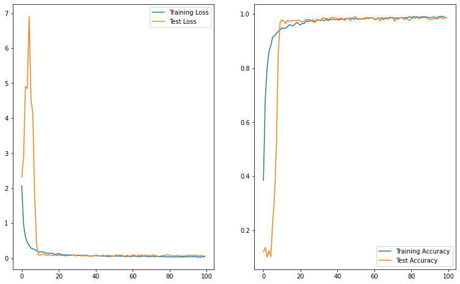

```python
visualize_loss_evolution(history_kaggle_flatten_CNN_all_train_AUG_soft)
```

#### Aug Havy

```python
aug_havy = ImageDataGenerator(
        rotation_range=16,
        shear_range=0.1,
        zoom_range=0.1,
        width_shift_range=0.2,
        height_shift_range=0.2,
        brightness_range=[0.6,1.4],
        fill_mode='nearest'
        )
```

```python
model_kaggle_flatten_CNN_all_train_AUG_havy = create_custom_CNN_from_kaggle(get_summary=True,
                                                                         glob_maxpool_or_flatten="flatten")
```

```
Model: "functional_21"
_________________________________________________________________
Layer (type)                 Output Shape              Param #
=================================================================
input_12 (InputLayer)        [(None, 20, 20, 1)]       0
_________________________________________________________________
conv2d_54 (Conv2D)           (None, 18, 18, 32)        320
_________________________________________________________________
batch_normalization_56 (Batc (None, 18, 18, 32)        128
_________________________________________________________________
conv2d_55 (Conv2D)           (None, 16, 16, 32)        9248
_________________________________________________________________
batch_normalization_57 (Batc (None, 16, 16, 32)        128
_________________________________________________________________
conv2d_56 (Conv2D)           (None, 8, 8, 32)          25632
_________________________________________________________________
batch_normalization_58 (Batc (None, 8, 8, 32)          128
_________________________________________________________________
dropout_24 (Dropout)         (None, 8, 8, 32)          0
_________________________________________________________________
conv2d_57 (Conv2D)           (None, 6, 6, 64)          18496
_________________________________________________________________
batch_normalization_59 (Batc (None, 6, 6, 64)          256
_________________________________________________________________
conv2d_58 (Conv2D)           (None, 4, 4, 64)          36928
_________________________________________________________________
batch_normalization_60 (Batc (None, 4, 4, 64)          256
_________________________________________________________________
conv2d_59 (Conv2D)           (None, 2, 2, 64)          102464
_________________________________________________________________
batch_normalization_61 (Batc (None, 2, 2, 64)          256
_________________________________________________________________
dropout_25 (Dropout)         (None, 2, 2, 64)          0
_________________________________________________________________
flatten_6 (Flatten)          (None, 256)               0
_________________________________________________________________
dense_25 (Dense)             (None, 128)               32896
_________________________________________________________________
batch_normalization_62 (Batc (None, 128)               512
_________________________________________________________________
dropout_26 (Dropout)         (None, 128)               0
_________________________________________________________________
dense_26 (Dense)             (None, 10)                1290
=================================================================
Total params: 228,938
Trainable params: 228,106
Non-trainable params: 832
_________________________________________________________________
```

```python
# Modeli compile edelim
opt = keras.optimizers.Adam()
loss_fn = keras.losses.CategoricalCrossentropy()

model_kaggle_flatten_CNN_all_train_AUG_havy.compile(optimizer = opt, loss = loss_fn,
                   metrics = ['accuracy'])
```

```python
model_name = "model_kaggle_flatten_CNN_all_train_AUG_havy"
model_checkpointer = ModelCheckpoint(save_dir + model_name + ".h5",
                                    monitor='val_loss',
                                    verbose=1,
                                    save_best_only=True,
                                    mode='min')
```

```python
history_kaggle_flatten_CNN_all_train_AUG_havy = model_kaggle_flatten_CNN_all_train_AUG_havy.fit(aug_havy.flow(X_train,y_train_ohe, batch_size=64),
                                                                        epochs = 100,
                                                                        steps_per_epoch = X_train.shape[0]//64,
                                                                        validation_data = (X_test, y_test_ohe),
                                                                        callbacks=[model_checkpointer]
                                                                        )
```

```
Epoch 00001: val_loss improved from inf to 2.59898, saving model to ./saved_models/model_kaggle_flatten_CNN_all_train_AUG_havy.h5
Epoch 00002: val_loss did not improve from 2.59898
Epoch 00003: val_loss did not improve from 2.59898
Epoch 00004: val_loss did not improve from 2.59898
Epoch 00005: val_loss did not improve from 2.59898
Epoch 00006: val_loss did not improve from 2.59898
Epoch 00007: val_loss did not improve from 2.59898
Epoch 00008: val_loss did not improve from 2.59898
Epoch 00009: val_loss did not improve from 2.59898
Epoch 00010: val_loss did not improve from 2.59898
Epoch 00011: val_loss did not improve from 2.59898
Epoch 00012: val_loss did not improve from 2.59898
Epoch 00013: val_loss did not improve from 2.59898
Epoch 00014: val_loss did not improve from 2.59898
Epoch 00015: val_loss did not improve from 2.59898
Epoch 00016: val_loss did not improve from 2.59898
Epoch 00017: val_loss did not improve from 2.59898
Epoch 00018: val_loss did not improve from 2.59898
Epoch 00019: val_loss did not improve from 2.59898
Epoch 00020: val_loss did not improve from 2.59898
Epoch 00021: val_loss did not improve from 2.59898
Epoch 00022: val_loss did not improve from 2.59898
Epoch 00023: val_loss did not improve from 2.59898
Epoch 00024: val_loss did not improve from 2.59898
Epoch 00025: val_loss did not improve from 2.59898
Epoch 00026: val_loss did not improve from 2.59898
Epoch 00027: val_loss did not improve from 2.59898
Epoch 00028: val_loss did not improve from 2.59898
Epoch 00029: val_loss did not improve from 2.59898
Epoch 00030: val_loss did not improve from 2.59898
Epoch 00031: val_loss did not improve from 2.59898
Epoch 00032: val_loss did not improve from 2.59898
Epoch 00033: val_loss did not improve from 2.59898
Epoch 00034: val_loss did not improve from 2.59898
Epoch 00035: val_loss did not improve from 2.59898
Epoch 00036: val_loss did not improve from 2.59898
Epoch 00037: val_loss did not improve from 2.59898
Epoch 00038: val_loss did not improve from 2.59898
Epoch 00039: val_loss did not improve from 2.59898
Epoch 00040: val_loss did not improve from 2.59898
```

[output cut: 45 more lines]

```
Epoch 00086: val_loss did not improve from 2.59898
Epoch 00087: val_loss did not improve from 2.59898
Epoch 00088: val_loss did not improve from 2.59898
Epoch 00089: val_loss did not improve from 2.59898
Epoch 00090: val_loss did not improve from 2.59898
Epoch 00091: val_loss did not improve from 2.59898
Epoch 00092: val_loss did not improve from 2.59898
Epoch 00093: val_loss did not improve from 2.59898
Epoch 00094: val_loss did not improve from 2.59898
Epoch 00095: val_loss did not improve from 2.59898
Epoch 00096: val_loss did not improve from 2.59898
Epoch 00097: val_loss did not improve from 2.59898
Epoch 00098: val_loss did not improve from 2.59898
Epoch 00099: val_loss did not improve from 2.59898
Epoch 00100: val_loss did not improve from 2.59898
```

```python
# best modeli lokalden tekrar yükleyip de test yapmak, overwrite gibi problemlerin önüne geçecektir
model_kaggle_flatten_CNN_all_train_AUG_havy = keras.models.load_model(save_dir + model_name + ".h5")
```

```python
model_kaggle_flatten_CNN_all_train_AUG_havy.evaluate(X_test, y_test_ohe)
```

```
[2.5989835262298584, 0.08900000154972076]
```

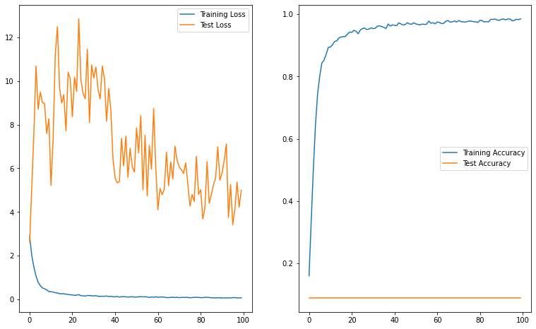

```python
visualize_loss_evolution(history_kaggle_flatten_CNN_all_train_AUG_havy)
```

Model hiçbir şey öğrenemiyordu. Debug için augmented iamgeları bir folder'a yazama ve pixel valuelarına baktım:

```
max pixel values:  249.0
min pixel values:  0.0
max pixel values:  202.0
min pixel values:  0.0
max pixel values:  255.0
min pixel values:  0.0
max pixel values:  183.0
min pixel values:  0.0
max pixel values:  255.0
min pixel values:  0.0
max pixel values:  255.0
min pixel values:  0.0
max pixel values:  255.0
min pixel values:  0.0
max pixel values:  166.0
min pixel values:  0.0
max pixel values:  255.0
min pixel values:  0.0
max pixel values:  255.0
min pixel values:  0.0
max pixel values:  199.0
min pixel values:  0.0
max pixel values:  242.0
min pixel values:  0.0
max pixel values:  238.0
min pixel values:  0.0
max pixel values:  255.0
min pixel values:  0.0
max pixel values:  255.0
min pixel values:  0.0
max pixel values:  199.0
min pixel values:  0.0
max pixel values:  255.0
min pixel values:  0.0
max pixel values:  255.0
min pixel values:  0.0
max pixel values:  255.0
min pixel values:  0.0
max pixel values:  170.0
min pixel values:  0.0
max pixel values:  255.0
min pixel values:  0.0
max pixel values:  255.0
min pixel values:  0.0
max pixel values:  255.0
min pixel values:  0.0
max pixel values:  156.0
min pixel values:  0.0
max pixel values:  255.0
min pixel values:  0.0
```

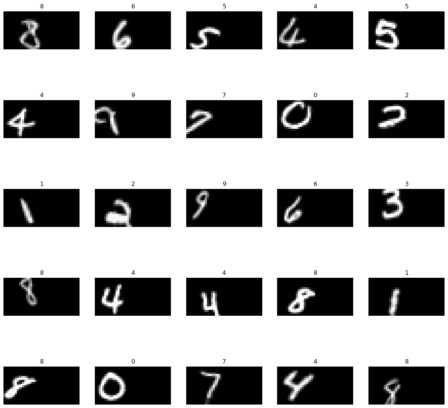

```python
aug_debug_save_dir = "./aug_images/"
if not(os.path.exists(aug_debug_save_dir)):
       os.mkdir(aug_debug_save_dir)
image_gen = aug_havy.flow(X_train_subset, y = y_train_subset_ohe, batch_size=1, save_to_dir=aug_debug_save_dir,
                    save_prefix="image", save_format="jpg", shuffle=False)
# for loop ile generatörü max_img_number kadar runlayıp çıktılara bakalım
total = 0
max_img_number = 25
plt.figure(figsize=(16, 16))
plt.tight_layout()
for image, label in image_gen:

    print("max pixel values: ", image.max())
    print("min pixel values: ", image.min())

    ax = plt.subplot(5, 5, total+1)
    plt.imshow(np.hstack((image[0], X_train_subset[total])), cmap = 'gray')
    plt.title(str(np.argmax(label[0])))
    plt.axis("off")

    # counterı artır
    total += 1
    # istenilen kadar image oluştuğunda break
    if total == max_img_number:
        break
plt.show()
```

Augmentationdan sonra pixel valueları tekrar 0-255 arasına transform ediliyormuş. Bunu bulmak epey bir zamanımı almıştı, iyi bir tecrübe oldu.

```python
# aug_havy'e 1/255. normalizasyonu eklersek problem çözülüyor
aug_havy_corrected = ImageDataGenerator(
        rescale=1./255,
        rotation_range=16,
        shear_range=0.1,
        zoom_range=0.1,
        width_shift_range=0.2,
        height_shift_range=0.2,
        brightness_range=[0.6,1.4],
        fill_mode='nearest'
        )
```

```
max pixel values:  1.0
min pixel values:  0.0
max pixel values:  0.87843144
min pixel values:  0.0
max pixel values:  0.8078432
min pixel values:  0.0
max pixel values:  0.7058824
min pixel values:  0.0
max pixel values:  1.0
min pixel values:  0.0
max pixel values:  1.0
min pixel values:  0.0
max pixel values:  1.0
min pixel values:  0.0
max pixel values:  1.0
min pixel values:  0.0
max pixel values:  1.0
min pixel values:  0.0
max pixel values:  1.0
min pixel values:  0.0
max pixel values:  1.0
min pixel values:  0.0
max pixel values:  0.6156863
min pixel values:  0.0
max pixel values:  0.9686275
min pixel values:  0.0
max pixel values:  1.0
min pixel values:  0.0
max pixel values:  1.0
min pixel values:  0.0
max pixel values:  0.86274517
min pixel values:  0.0
max pixel values:  0.8235295
min pixel values:  0.0
max pixel values:  0.80392164
min pixel values:  0.0
max pixel values:  0.86274517
min pixel values:  0.0
max pixel values:  0.9686275
min pixel values:  0.0
max pixel values:  1.0
min pixel values:  0.0
max pixel values:  1.0
min pixel values:  0.0
max pixel values:  1.0
min pixel values:  0.0
max pixel values:  1.0
min pixel values:  0.0
max pixel values:  0.72156864
min pixel values:  0.0
```

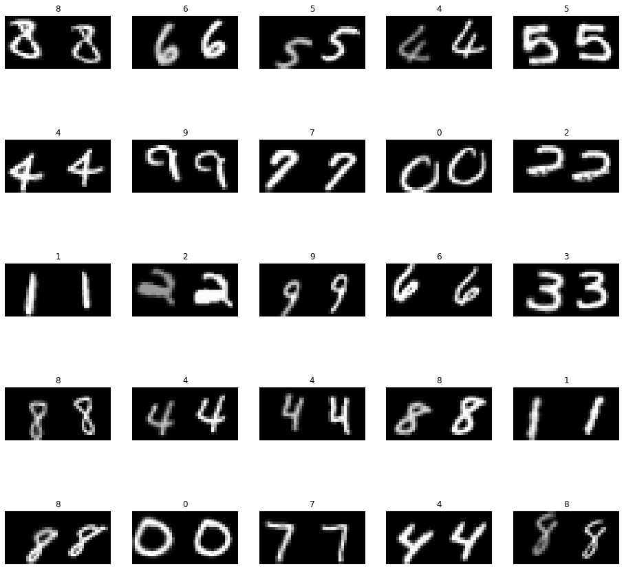

```python
# pixel değerlerini kontrol edelim

image_gen = aug_havy_corrected.flow(X_train_subset, y = y_train_subset_ohe, batch_size=1, save_to_dir=aug_debug_save_dir,
                    save_prefix="image", save_format="jpg", shuffle=False)
# for loop ile generatörü max_img_number kadar runlayıp çıktılara bakalım
total = 0
max_img_number = 25
plt.figure(figsize=(16, 16))
plt.tight_layout()
for image, label in image_gen:

    print("max pixel values: ", image.max())
    print("min pixel values: ", image.min())

    ax = plt.subplot(5, 5, total+1)
    plt.imshow(np.hstack((image[0], X_train_subset[total])), cmap = 'gray')
    plt.title(str(np.argmax(label[0])))
    plt.axis("off")

    # counterı artır
    total += 1
    # istenilen kadar image oluştuğunda break
    if total == max_img_number:
        break
plt.show()
```

Inputlar olması gerektiği gibi. rescale=1./255 günü kurtardı.

```python
model_kaggle_flatten_CNN_all_train_AUG_havy_corrected = create_custom_CNN_from_kaggle(get_summary=True,
                                                                         glob_maxpool_or_flatten="flatten")
```

```
Model: "functional_27"
_________________________________________________________________
Layer (type)                 Output Shape              Param #
=================================================================
input_15 (InputLayer)        [(None, 20, 20, 1)]       0
_________________________________________________________________
conv2d_72 (Conv2D)           (None, 18, 18, 32)        320
_________________________________________________________________
batch_normalization_77 (Batc (None, 18, 18, 32)        128
_________________________________________________________________
conv2d_73 (Conv2D)           (None, 16, 16, 32)        9248
_________________________________________________________________
batch_normalization_78 (Batc (None, 16, 16, 32)        128
_________________________________________________________________
conv2d_74 (Conv2D)           (None, 8, 8, 32)          25632
_________________________________________________________________
batch_normalization_79 (Batc (None, 8, 8, 32)          128
_________________________________________________________________
dropout_33 (Dropout)         (None, 8, 8, 32)          0
_________________________________________________________________
conv2d_75 (Conv2D)           (None, 6, 6, 64)          18496
_________________________________________________________________
batch_normalization_80 (Batc (None, 6, 6, 64)          256
_________________________________________________________________
conv2d_76 (Conv2D)           (None, 4, 4, 64)          36928
_________________________________________________________________
batch_normalization_81 (Batc (None, 4, 4, 64)          256
_________________________________________________________________
conv2d_77 (Conv2D)           (None, 2, 2, 64)          102464
_________________________________________________________________
batch_normalization_82 (Batc (None, 2, 2, 64)          256
_________________________________________________________________
dropout_34 (Dropout)         (None, 2, 2, 64)          0
_________________________________________________________________
flatten_8 (Flatten)          (None, 256)               0
_________________________________________________________________
dense_31 (Dense)             (None, 128)               32896
_________________________________________________________________
batch_normalization_83 (Batc (None, 128)               512
_________________________________________________________________
dropout_35 (Dropout)         (None, 128)               0
_________________________________________________________________
dense_32 (Dense)             (None, 10)                1290
=================================================================
Total params: 228,938
Trainable params: 228,106
Non-trainable params: 832
_________________________________________________________________
```

```python
# Modeli compile edelim
opt = keras.optimizers.Adam()
loss_fn = keras.losses.CategoricalCrossentropy()

model_kaggle_flatten_CNN_all_train_AUG_havy_corrected.compile(optimizer = opt, loss = loss_fn,
                   metrics = ['accuracy'])
```

```python
model_name = "model_kaggle_flatten_CNN_all_train_AUG_havy_corrected"
model_checkpointer = ModelCheckpoint(save_dir + model_name + ".h5",
                                    monitor='val_loss',
                                    verbose=1,
                                    save_best_only=True,
                                    mode='min')
```

```python
history_kaggle_flatten_CNN_all_train_AUG_havy_corrected = model_kaggle_flatten_CNN_all_train_AUG_havy_corrected.fit(aug_havy_corrected.flow(X_train,y_train_ohe, batch_size=64),
                                                                        epochs = 100,
                                                                        steps_per_epoch = X_train.shape[0]//64,
                                                                        validation_data = (X_test, y_test_ohe),
                                                                        callbacks=[model_checkpointer]
                                                                        )
```

```
Epoch 00001: val_loss improved from inf to 2.26510, saving model to ./saved_models/model_kaggle_flatten_CNN_all_train_AUG_havy_corrected.h5
Epoch 00002: val_loss did not improve from 2.26510
Epoch 00003: val_loss did not improve from 2.26510
Epoch 00004: val_loss did not improve from 2.26510
Epoch 00005: val_loss did not improve from 2.26510
Epoch 00006: val_loss did not improve from 2.26510
Epoch 00007: val_loss did not improve from 2.26510
Epoch 00008: val_loss improved from 2.26510 to 0.76063, saving model to ./saved_models/model_kaggle_flatten_CNN_all_train_AUG_havy_corrected.h5
Epoch 00009: val_loss improved from 0.76063 to 0.28631, saving model to ./saved_models/model_kaggle_flatten_CNN_all_train_AUG_havy_corrected.h5
Epoch 00010: val_loss improved from 0.28631 to 0.14903, saving model to ./saved_models/model_kaggle_flatten_CNN_all_train_AUG_havy_corrected.h5
Epoch 00011: val_loss improved from 0.14903 to 0.11026, saving model to ./saved_models/model_kaggle_flatten_CNN_all_train_AUG_havy_corrected.h5
Epoch 00012: val_loss did not improve from 0.11026
Epoch 00013: val_loss did not improve from 0.11026
Epoch 00014: val_loss improved from 0.11026 to 0.10867, saving model to ./saved_models/model_kaggle_flatten_CNN_all_train_AUG_havy_corrected.h5
Epoch 00015: val_loss did not improve from 0.10867
Epoch 00016: val_loss did not improve from 0.10867
Epoch 00017: val_loss did not improve from 0.10867
Epoch 00018: val_loss did not improve from 0.10867
Epoch 00019: val_loss improved from 0.10867 to 0.09022, saving model to ./saved_models/model_kaggle_flatten_CNN_all_train_AUG_havy_corrected.h5
Epoch 00020: val_loss did not improve from 0.09022
Epoch 00021: val_loss improved from 0.09022 to 0.08577, saving model to ./saved_models/model_kaggle_flatten_CNN_all_train_AUG_havy_corrected.h5
Epoch 00022: val_loss improved from 0.08577 to 0.06465, saving model to ./saved_models/model_kaggle_flatten_CNN_all_train_AUG_havy_corrected.h5
Epoch 00023: val_loss did not improve from 0.06465
Epoch 00024: val_loss did not improve from 0.06465
Epoch 00025: val_loss did not improve from 0.06465
Epoch 00026: val_loss did not improve from 0.06465
Epoch 00027: val_loss did not improve from 0.06465
Epoch 00028: val_loss did not improve from 0.06465
Epoch 00029: val_loss did not improve from 0.06465
Epoch 00030: val_loss did not improve from 0.06465
Epoch 00031: val_loss did not improve from 0.06465
Epoch 00032: val_loss did not improve from 0.06465
Epoch 00033: val_loss did not improve from 0.06465
Epoch 00034: val_loss did not improve from 0.06465
Epoch 00035: val_loss did not improve from 0.06465
Epoch 00036: val_loss did not improve from 0.06465
Epoch 00037: val_loss did not improve from 0.06465
Epoch 00038: val_loss improved from 0.06465 to 0.05815, saving model to ./saved_models/model_kaggle_flatten_CNN_all_train_AUG_havy_corrected.h5
Epoch 00039: val_loss did not improve from 0.05815
Epoch 00040: val_loss did not improve from 0.05815
```

[output cut: 45 more lines]

```
Epoch 00086: val_loss did not improve from 0.05068
Epoch 00087: val_loss did not improve from 0.05068
Epoch 00088: val_loss did not improve from 0.05068
Epoch 00089: val_loss did not improve from 0.05068
Epoch 00090: val_loss did not improve from 0.05068
Epoch 00091: val_loss did not improve from 0.05068
Epoch 00092: val_loss did not improve from 0.05068
Epoch 00093: val_loss did not improve from 0.05068
Epoch 00094: val_loss did not improve from 0.05068
Epoch 00095: val_loss did not improve from 0.05068
Epoch 00096: val_loss improved from 0.05068 to 0.04884, saving model to ./saved_models/model_kaggle_flatten_CNN_all_train_AUG_havy_corrected.h5
Epoch 00097: val_loss did not improve from 0.04884
Epoch 00098: val_loss did not improve from 0.04884
Epoch 00099: val_loss did not improve from 0.04884
Epoch 00100: val_loss did not improve from 0.04884
```

```python
# best modeli lokalden tekrar yükleyip de test yapmak, overwrite gibi problemlerin önüne geçecektir
model_kaggle_flatten_CNN_all_train_AUG_havy_corrected = keras.models.load_model(save_dir + model_name + ".h5")
```

```python
model_kaggle_flatten_CNN_all_train_AUG_havy_corrected.evaluate(X_test, y_test_ohe)
```

```
[0.04884013533592224, 0.9900000095367432]
```

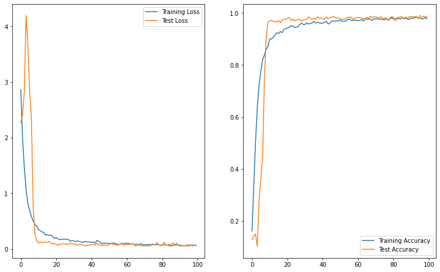

```python
visualize_loss_evolution(history_kaggle_flatten_CNN_all_train_AUG_havy_corrected)
```

# Başarı Oranlarının Hesaplanması

### İlk 1000 veriyle eğitilen model için Confusion Matrix Oluşturulması

```python
predictions_subset = model_kaggle_flatten_CNN_subset_train.predict(X_test)
predicted_classes = np.argmax(predictions_subset, axis = -1)
predicted_classes
```

```
array([5, 6, 5, 9, 5, 0, 3, 3, 5, 0, 8, 4, 1, 0, 5, 3, 0, 5, 6, 2, 1, 9,
       4, 8, 4, 5, 9, 0, 9, 9, 8, 1, 2, 5, 3, 6, 7, 0, 6, 7, 7, 8, 4, 9,
       0, 0, 6, 2, 2, 2, 8, 7, 3, 4, 9, 0, 5, 8, 4, 4, 6, 3, 0, 5, 3, 0,
       9, 1, 9, 9, 2, 1, 4, 1, 5, 9, 5, 6, 4, 0, 0, 6, 7, 0, 5, 7, 3, 6,
       1, 6, 0, 5, 8, 4, 4, 5, 4, 3, 2, 5, 0, 7, 4, 3, 9, 6, 1, 2, 7, 8,
       9, 3, 9, 1, 2, 0, 9, 9, 5, 0, 0, 0, 2, 2, 5, 0, 1, 5, 9, 9, 3, 4,
       9, 8, 6, 8, 5, 4, 8, 3, 9, 0, 1, 0, 3, 9, 6, 6, 7, 4, 4, 7, 4, 2,
       4, 5, 2, 6, 0, 3, 1, 6, 2, 2, 6, 4, 9, 0, 9, 7, 7, 3, 3, 9, 6, 5,
       9, 6, 3, 5, 0, 5, 2, 7, 4, 3, 4, 3, 9, 5, 1, 5, 0, 5, 4, 5, 6, 6,
       4, 3, 4, 3, 2, 9, 1, 3, 4, 7, 6, 5, 0, 4, 5, 4, 6, 7, 6, 8, 5, 3,
       3, 7, 2, 1, 8, 9, 2, 6, 3, 5, 3, 5, 4, 9, 0, 3, 6, 1, 3, 0, 8, 7,
       3, 8, 7, 1, 9, 3, 3, 6, 9, 9, 9, 6, 2, 2, 5, 4, 0, 5, 6, 2, 0, 1,
       8, 8, 7, 5, 0, 1, 5, 1, 0, 6, 7, 4, 6, 9, 5, 3, 3, 3, 4, 7, 0, 6,
       4, 1, 5, 8, 1, 6, 5, 7, 2, 4, 1, 1, 2, 2, 0, 5, 8, 5, 9, 7, 7, 0,
       9, 6, 9, 2, 2, 5, 3, 4, 5, 1, 9, 5, 6, 9, 0, 3, 2, 1, 1, 8, 7, 7,
```

[output cut: 31 more lines]

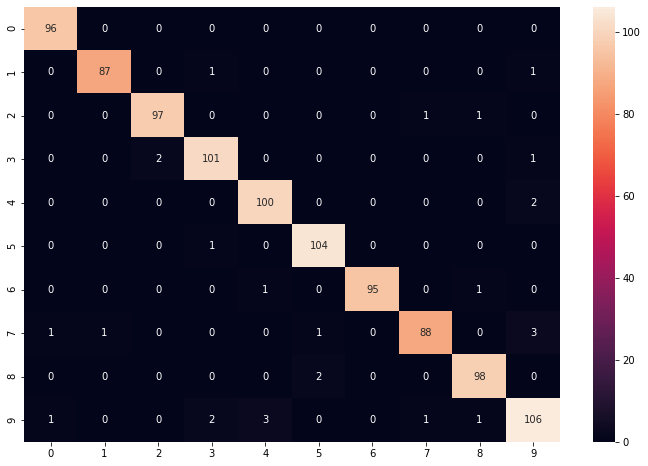

```python
plt.figure(figsize = (12, 8))
cm = confusion_matrix(y_test, predicted_classes)
sns.heatmap(cm, annot = True, fmt = 'd')
```

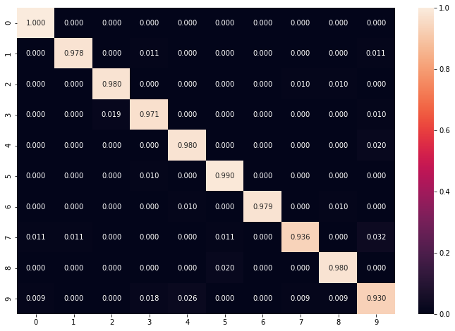

```python
plt.figure(figsize = (12, 8))
cm = confusion_matrix(y_test, predicted_classes, normalize='true')
sns.heatmap(cm, annot = True, fmt = '.3f')
```

```python
model_kaggle_flatten_CNN_subset_train.evaluate(X_test, y_test_ohe)
```

```
[0.12656162679195404, 0.972000002861023]
```

```python
print(classification_report(y_test, predicted_classes))
```

```
              precision    recall  f1-score   support

           0       0.98      1.00      0.99        96
           1       0.99      0.98      0.98        89
           2       0.98      0.98      0.98        99
           3       0.96      0.97      0.97       104
           4       0.96      0.98      0.97       102
           5       0.97      0.99      0.98       105
           6       1.00      0.98      0.99        97
           7       0.98      0.94      0.96        94
           8       0.97      0.98      0.98       100
           9       0.94      0.93      0.93       114

    accuracy                           0.97      1000
   macro avg       0.97      0.97      0.97      1000
weighted avg       0.97      0.97      0.97      1000
```

### Bütün veriyle eğitilen model için Confusion Matrix Oluşturulması

```python
predictions_all_train = model_kaggle_flatten_CNN_all_train.predict(X_test)
predicted_classes_all_train = np.argmax(predictions_all_train, axis = -1)
```

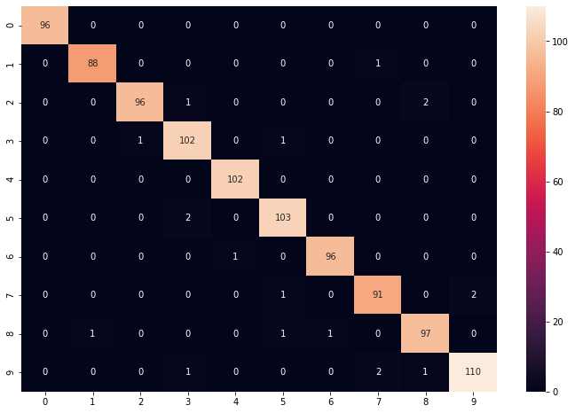

```python
plt.figure(figsize = (12, 8))
cm = confusion_matrix(y_test, predicted_classes_all_train)
sns.heatmap(cm, annot = True, fmt = 'd')
```

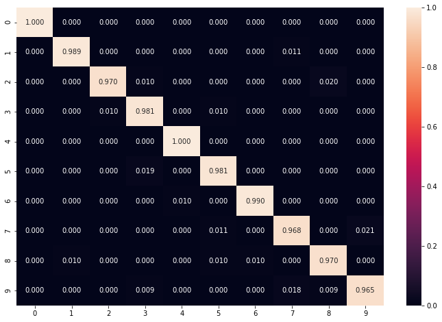

```python
plt.figure(figsize = (12, 8))
cm = confusion_matrix(y_test, predicted_classes_all_train, normalize='true')
sns.heatmap(cm, annot = True, fmt = '.3f')
```

```python
model_kaggle_flatten_CNN_all_train.evaluate(X_test, y_test_ohe)
```

```
[0.055416539311409, 0.9810000061988831]
```

```python
print(classification_report(y_test, predicted_classes_all_train))
```

```
              precision    recall  f1-score   support

           0       1.00      1.00      1.00        96
           1       0.99      0.99      0.99        89
           2       0.99      0.97      0.98        99
           3       0.96      0.98      0.97       104
           4       0.99      1.00      1.00       102
           5       0.97      0.98      0.98       105
           6       0.99      0.99      0.99        97
           7       0.97      0.97      0.97        94
           8       0.97      0.97      0.97       100
           9       0.98      0.96      0.97       114

    accuracy                           0.98      1000
   macro avg       0.98      0.98      0.98      1000
weighted avg       0.98      0.98      0.98      1000
```

### Bütün veride augmentation kullanılarak eğitilen model için Confusion Matrix Oluşturulması

```python
predictions_aug = model_kaggle_flatten_CNN_all_train_AUG_havy_corrected.predict(X_test)
predicted_classes_aug = np.argmax(predictions_aug, axis = -1)
```

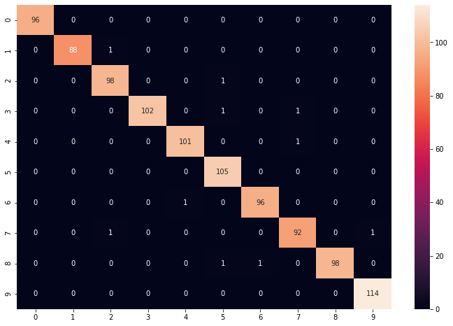

```python
plt.figure(figsize = (12, 8))
cm = confusion_matrix(y_test, predicted_classes_aug)
sns.heatmap(cm, annot = True, fmt = 'd')
```

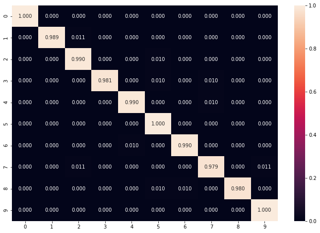

```python
plt.figure(figsize = (12, 8))
cm = confusion_matrix(y_test, predicted_classes_aug, normalize='true')
sns.heatmap(cm, annot = True, fmt = '.3f')
```

```python
model_kaggle_flatten_CNN_all_train_AUG_havy_corrected.evaluate(X_test, y_test_ohe)
```

```
[0.04884013533592224, 0.9900000095367432]
```

```python
print(classification_report(y_test, predicted_classes_aug))
```

```
              precision    recall  f1-score   support

           0       1.00      1.00      1.00        96
           1       1.00      0.99      0.99        89
           2       0.98      0.99      0.98        99
           3       1.00      0.98      0.99       104
           4       0.99      0.99      0.99       102
           5       0.97      1.00      0.99       105
           6       0.99      0.99      0.99        97
           7       0.98      0.98      0.98        94
           8       1.00      0.98      0.99       100
           9       0.99      1.00      1.00       114

    accuracy                           0.99      1000
   macro avg       0.99      0.99      0.99      1000
weighted avg       0.99      0.99      0.99      1000
```

Confusion matrix'den class bazlı accuracy'miz ne durumda, model hangi given class'ı hangisiyle karıştırıyor şeklindeki bilgileri okuyabiliyoruz. Multiclass problemlerde bu yüzden daha fazla bilgi sağlamış oluyor. Örneğin, 7 olduğu bilinen test örneklerinde augmented model sadece 1 kez 7'ye 9, bir kez de 2 demiş. Bunun gibi hata analizleriyle, hem görsel hem numeric analizler yapıp veriye ona göre augmentationlar uygulayabiliriz.

Veri setinin büyümesiyle modelimizin başarısı giderek arttı. Modellerimiz, özellikle neural netler, beslendiği ölçüde genelleştirme becerisine sahip oluyor. Bu çalışmada bunu görmüş olduk.

# İleriki Çalışmalar

- Daha fazla augmentation deneyi yapılabilir
- Stopping koyarak daha fazla epochla trainler atılabilir